# Explorations

Taishi Nakase

5/29/2020

## Packages

```r
required <- c("adaptivetau", "formula.tools", "purrr")
to_install <- setdiff(required, row.names(installed.packages()))
# if (length(to_install)) install.packages(to_install)
```

```r
library(magrittr)
library(ggplot2)
library(tidyverse)
library(iterpc)
library(deSolve)
library(R.utils)
```

## Single population stochastic model of measles epidemic

Consider a population of `N` individuals, of which `I0` are infections, `p` % are vaccinated and the rest are susceptible. The disease spreads in the population with an infectious contact rate of `beta` / person / time unit. Infected individuals remain in a latency period of mean duration `1 / sigma` time units before they become infectious from which state they recover at the rate of `gamma` / time unit. The following function runs stochastic individual-based simulations of this model for a duration of `tf` time units, using the algorithm coded in the `f` function. The algorithm implements adaptive tau leaping to approximate the trajectory of a continuous-time stochastic process (the Gillespie stochastic simulation algorithm). This model incorporates demographic stochasticity, which is defined as population processes that are driven by the random nature of events at the level of the individual. Furthermore, we consider the SEIR model; that is, the host can be categorized as suscepitble, infected but not yet infectious, infectious or recovered.

Note that the model makes the assumption that the infection, getting infectious and recovery process are independent Poisson processes.

```r
seir <- function(N = 1e6, I0 = 1, p = 0, beta = 5, sigma = 1/7, gamma = 1/7,
                 tf = 100, f = adaptivetau::ssa.adaptivetau, ...) {
  vaccinated <- round(p * (N - I0))
  x0 <- c(S = N - I0 - vaccinated, E = 0, I = I0, R = vaccinated)
  transitions <- list(c(S = -1, E = +1),  # infection
                      c(E = -1, I = +1),  # getting infectious
                      c(I = -1, R = +1))  # recovery
  lvrates <- function(x, params, t) {with(c(x, params),
                                          c(beta * S * I / N,
                                            sigma * E,
                                            gamma * I))
  }
  data.frame(f(x0, transitions, lvrates,
               list(beta = beta, sigma = sigma, gamma = gamma), tf = tf, ...))
}
```

Note that with the default parameter values, we have an $R_0$ of
$$R_0 = \frac{\beta}{\sigma + \gamma} = \frac{5}{1/7 + 1/7} = 17.5$$
Note that this $R_0$ is comparable to that of measles, which has an estimated $R_0$ of 16-18. Since $R_0$ is large, there is a restorative force that drives the population away from extinction whenever the number of infectious individuals is low.

Let’s try it with default parameter values.

```r
sim1 <- seir()
```

which gives,

```r
head(sim1)
```

```
##        time      S E I R
## 1 0.0000000 999999 0 1 0
## 2 0.5474577 999998 1 1 0
## 3 0.5904699 999997 2 1 0
## 4 0.6113259 999996 3 1 0
## 5 0.6329150 999995 4 1 0
## 6 0.9198794 999994 5 1 0
```

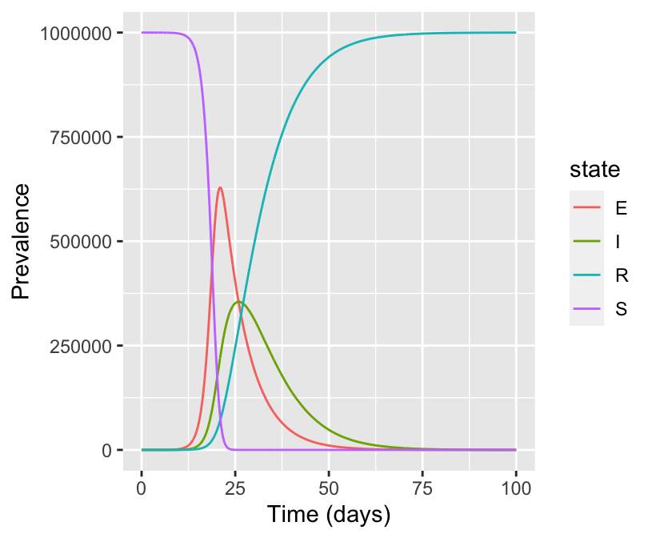

```r
sim1 %>% gather(key = state, value = number, S, E, I, R) %>%
  ggplot(aes(x = time, y = number, color = state, group = state)) + geom_line() +
  labs(x = "Time (days)", y = "Prevalence")
```

### Running simulations in parallel

The following function runs any expression `expr` `n` times in parallel on `mc.cores`:

```r
mcreplicate <- function(n, expr, mc.cores = NULL) {
  if (is.null(mc.cores)) mc.cores <- parallel::detectCores() - 1
  parallel::mclapply(integer(n), eval.parent(substitute(function(...) expr)), mc.cores = mc.cores)
}
```

Let’s try it:

```r
sim2 <- mcreplicate(10, seir())
```

The following function plots the epi curves from a list of simulations:

```r
plot_list <- function(formula, ls, xlim = NULL, ylim = NULL, col = adjustcolor("black", 0.1), ...) {
  x <- purrr::map(ls, purrr::pluck, as.character(formula.tools::rhs(formula)))
  y <- purrr::map(ls, purrr::pluck, as.character(formula.tools::lhs(formula)))
  if (is.null(xlim)) xlim <- c(0, max(unlist(x)))
  if (is.null(ylim)) ylim <- c(0, max(unlist(y)))
  plot(NA, xlim = xlim, ylim = ylim, ...)
  purrr::walk2(x, y, lines, col = col)
}
```

Let’s try it: Plots the epi curves of 10 independent simulations.

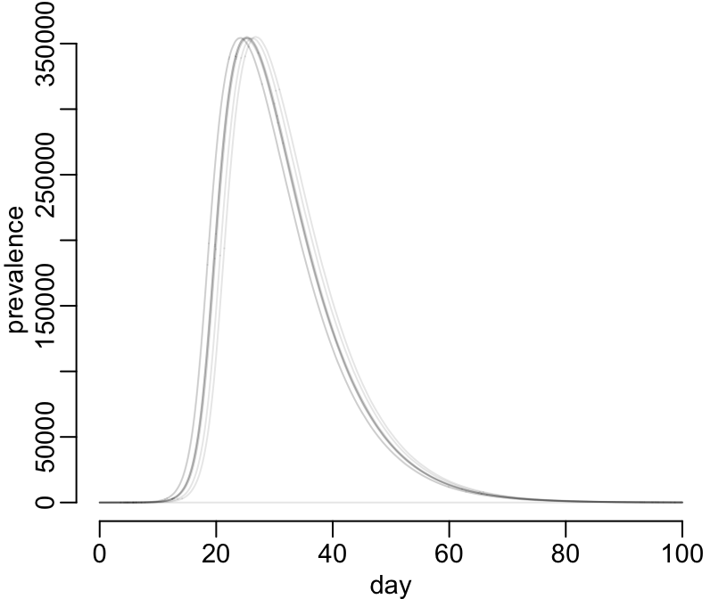

```r
plot_list(I ~ time, sim2, type = "l", xlab = "day", ylab = "prevalence")
```

Let’s consider 1,000 simulations of the previous model for various vaccine coverages. For that, let’s first consider the following `simulate()` function:

```r
simulate <- function(x) purrr::rerun(1000, seir(p = x, tf = 1000))
```

Let’s use this function in parallel for 11 values of vaccine coverage (1’):

```r
sim3 <- parallel::mclapply(seq(0, 1, 0.1), simulate, mc.cores = parallel::detectCores() - 1)
```

Let’s plot the $11 \times 1000 = 11000$ epi curves:

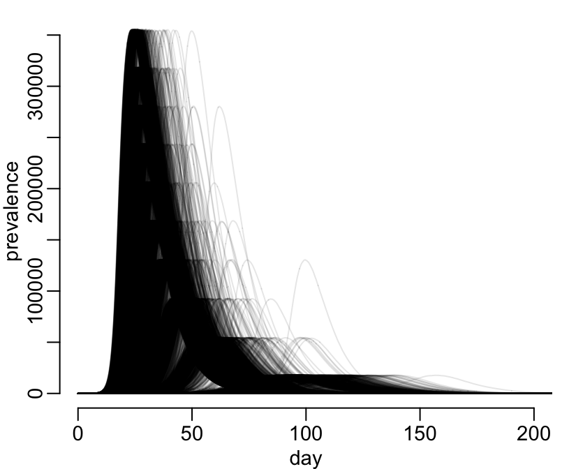

```r
plot_list(I ~ time, unlist(sim3, FALSE), type = "l", xlab = "day", ylab = "prevalence", xlim = c(0, 200))
```

### Probability of an epidemic and epidemic size with respect to vaccine coverage

The following function computes the average epidemic size in a population of 1,000,000 individuals, for a number of vaccine coverage values (in vector `p`) with `n` replications for each vaccine coverage value:

```r
avg_epi_size <- function(p = 0.5, N = 1e6, n = 1000, t = 0.1, nbcores = NULL, ...) {
  library(dplyr)
  if (is.null(nbcores)) nbcores <- parallel::detectCores() - 1
  simulate <- function(x) seir(p = x, N = N, ...)
  p %>% parallel::mclapply(function(x) purrr::rerun(n, dplyr::last(simulate(x)$R)),
                                   mc.cores = nbcores) %>%
    purrr::map(function(x) data.frame(unlist(x))) %>%
    purrr::map(function(x) data.frame(mean(x$unlist.x))) %>%
    dplyr::bind_rows() %>%
    dplyr::transmute(p = p, avg_epi_size = as.integer(mean.x.unlist.x. - round(p * (N - 1))))
}
```

Let’s try it (40’’):

```r
sim4 <- avg_epi_size(seq(0, 1, 0.1), tf = 1000)
```

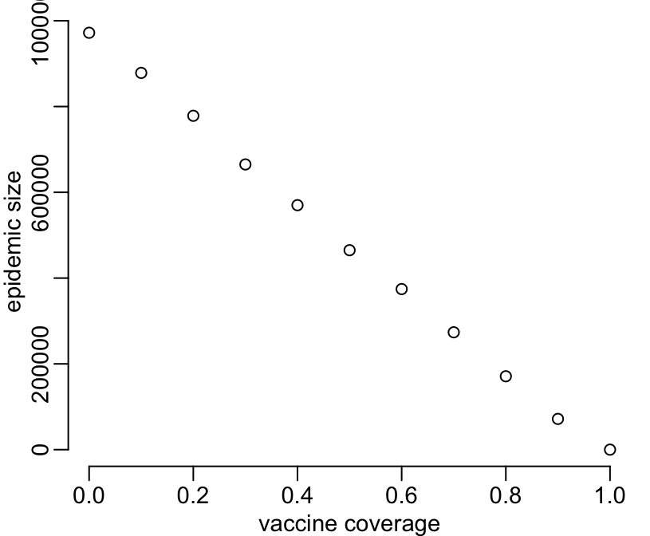

```r
plot(avg_epi_size ~ p, sim4, xlab = "vaccine coverage", ylab = "epidemic size")
```

As expected, there is a negative correlation between vaccine coverage and epidemic size. In particular, there is a linear relationship between vaccine coverage and epidemic size.

Let’s see in more detail what happens between the vaccine coverage 80% and 100% (1’):

```r
sim5 <- avg_epi_size(seq(0.8, 1, 0.01), tf = 1000)
```

Let’s see that:

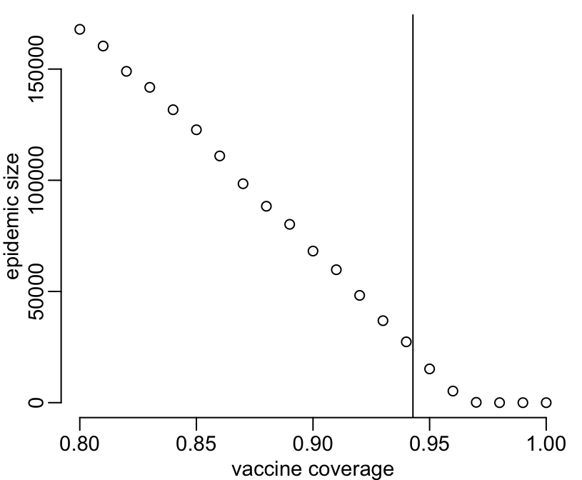

```r
plot(avg_epi_size ~ p, sim5, xlab = "vaccine coverage", ylab = "epidemic size")
abline(v = (1 - 1/R_0))
```

The vertical line shows the critical level of vaccination.

The critical level of vaccination needed to eradicate an infectious disease $V_C$ is given by
$$\begin{aligned}
V_C = 1 - \frac{1}{R_0} = 1 - \frac{1}{17.5} \approx 0.9429
\end{aligned}$$

Let’s combine with previous simulation:

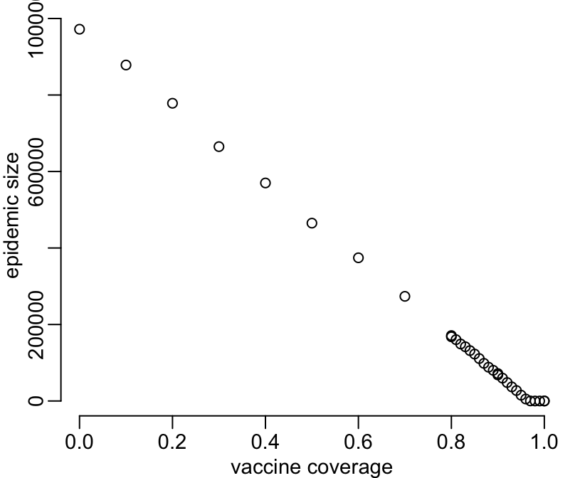

```r
plot(avg_epi_size ~ p, dplyr::bind_rows(sim4, sim5),
     xlab = "vaccine coverage", ylab = "epidemic size")
```

and:

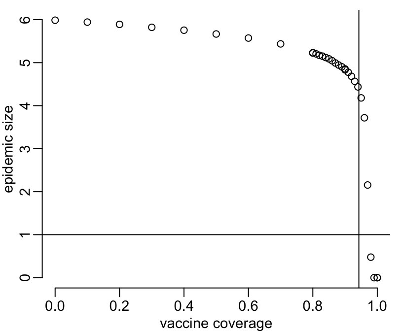

```r
plot(log10(avg_epi_size) ~ p, dplyr::bind_rows(sim4, sim5),
     xlab = "vaccine coverage", ylab = "epidemic size")
abline(h = log10(10))
abline(v = (1 - 1/R_0))
```

The horizontal line shows total number of secondary cases equal to 10. In what follows we will consider this (arbitrary) threshold value to define an epidemic. The following function uses this threshold to compute the probability that an epidemic occurs and the expected epidemic size in case there is an epidemic.

```r
epi_proba_mean_size <- function(p = 0.5, I0 = 1, N = 1e6, n = 1000, t = 0.1, threshold = 10,
                                nbcores = NULL, ...) {
  library(dplyr)
  if (is.null(nbcores)) nbcores <- parallel::detectCores() - 1
  simulate <- function(x) seir(p = x, N = N, ...)

  f <- function(x) {
    R_size <- unlist(purrr::rerun(n, dplyr::last(simulate(x)$R)))
    epi_size <- R_size - round(x * (N - 1))
    sel <- epi_size > threshold
    c(epi_proba = mean(sel),
      mean_epi_size = mean(epi_size[sel]))
  }

  p %>%
    parallel::mclapply(f, mc.cores = nbcores) %>%
    purrr::map(~ t(.) %>% as.data.frame()) %>%
    purrr::map2(p, ~ dplyr::mutate(.x, p = .y)) %>%
    dplyr::bind_rows() %>%
    dplyr::select(p, dplyr::everything())
}
```

Let’s try it (77’):

```r
sim6 <- epi_proba_mean_size(seq(0, 1, 0.001), tf = 1000)
```

Let’s see the effect of vaccine coverage on the probability of an epidemic.

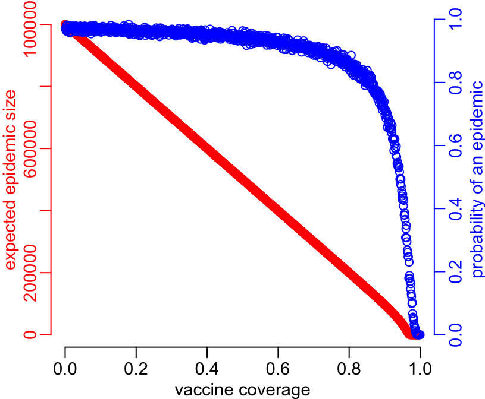

```r
col1 <- "red"
col2 <- "blue"
plot(mean_epi_size ~ p, sim6, xlab = "vaccine coverage",
     ylab = NA, col = col1, axes = FALSE)
axis(1)
axis(2, col = col1, col.axis = col1)
title(ylab = "expected epidemic size", col.lab = col1)
par(new = TRUE)
plot(epi_proba ~ p, sim6, ann = FALSE, col = col2, axes = FALSE)
axis(4, col = col2, col.axis = col2)
mtext("probability of an epidemic", 4, 1.5, col = col2)
```

There is a strong linear relationship between vaccine coverage and the expected epidemic size. Furthermore, the effects of a decrease in vaccine coverage are particularly important for high vaccine coverages. Let’s zoom up on the higher vaccine coverage region.

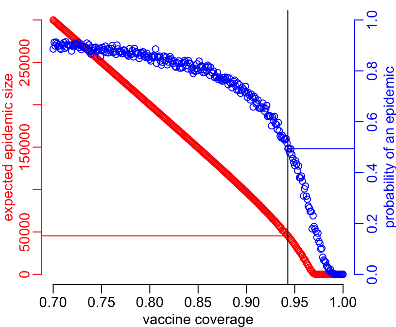

```r
sim6b <- dplyr::filter(sim6, p >= 0.7)

pc <- 1 - 1/R_0
tmp <- tail(dplyr::filter(sim6, p < round(pc, 3) + 0.001), 1)

col1 <- "red"
col2 <- "blue"
plot(mean_epi_size ~ p, sim6b, xlab = "vaccine coverage", ylab = NA,
     col = col1, axes = FALSE)
axis(1)
axis(2, col = col1, col.axis = col1)
title(ylab = "expected epidemic size", col.lab = col1)
segments(0, tmp$mean_epi_size, pc, tmp$mean_epi_size, col = col1)
par(new = TRUE)
plot(epi_proba ~ p, sim6b, ann = FALSE, col = col2, axes = FALSE, ylim = 0:1)
axis(4, col = col2, col.axis = col2)
mtext("probability of an epidemic", 4, 1.5, col = col2)
segments(pc, tmp$epi_proba, 1.1, tmp$epi_proba, col = col2)
abline(v = pc)
```

Note that, at the theoretically safe vaccine coverage $p_c = 1 - 1/R_0 = 94.3 \%$, there is still a probability of 0.494 to have an epidemic of 45407 individuals.

### Epidynamics for varying population sizes

Let’s simulate for other population sizes:

```r
sim7 <- epi_proba_mean_size(seq(0, 1, 0.001), N = 1e5, tf = 1000)
sim8 <- epi_proba_mean_size(seq(0, 1, 0.001), N = 1e4, tf = 1000)
sim9 <- epi_proba_mean_size(seq(0, 1, 0.001), N = 1e3, tf = 1000)
```

Let’s put the 4 simulations together.

```r
four_sims <- dplyr::bind_rows(list(sim9, sim8, sim7, sim6), .id = "sim")
four_sims <- four_sims[sample(nrow(four_sims)), ] %>%
  dplyr::mutate(sim = as.integer(sim),
                epi_size = mean_epi_size / (10^(sim + 2)))
```

Let’s compare the probabilities of an epidemic for the 4 population sizes.

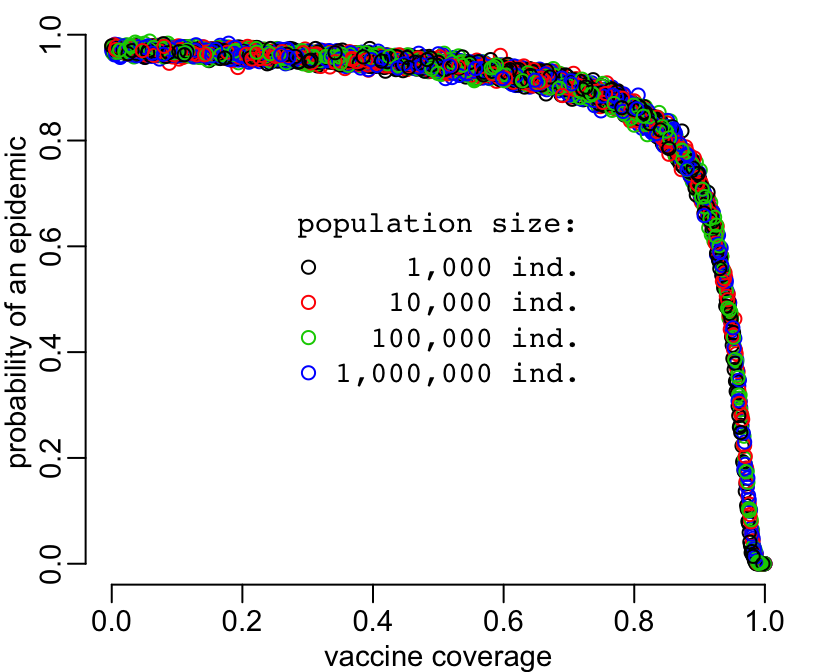

```r
plot(epi_proba ~ p, four_sims, xlab = "vaccine coverage",
     ylab = "probability of an epidemic", col = four_sims$sim)
op <- par(family = "mono")
legend("center", legend = c("    1,000 ind.", "   10,000 ind.", "  100,000 ind.", "1,000,000 ind."),
       col = 1:4, pch = 1, bty = "n", title = "population size:")
```

```r
par(op)
```

The probabilities of an epidemic for the 4 population sizes do not greatly differ across vaccine coverage levels.

Let’s now compare the expected epidemic size for the 4 population sizes:

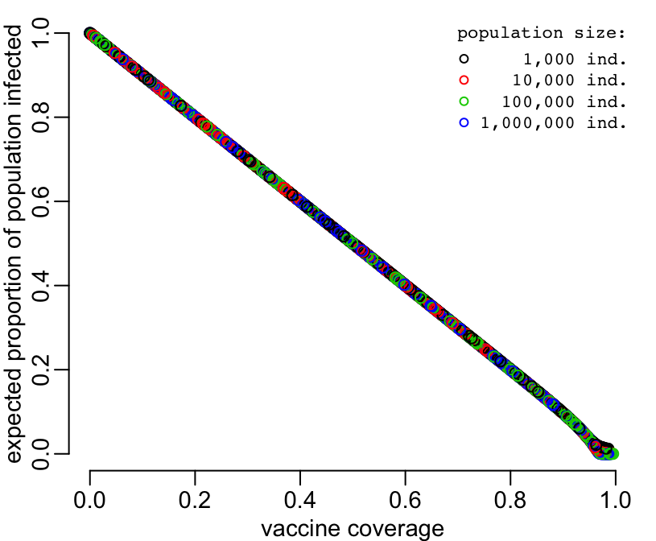

```r
plot(epi_size ~ p, four_sims, xlab = "vaccine coverage",
     ylab = "expected proportion of population infected", col =
       four_sims$sim)
op <- par(family = "mono")
legend("topright", legend = c("    1,000 ind.", "   10,000 ind.", "  100,000 ind.", "1,000,000 ind."),
       col = 1:4, pch = 1, bty = "n", title = "population size:", cex = 0.75)
```

```r
par(op)
```

Let’s zoom in:

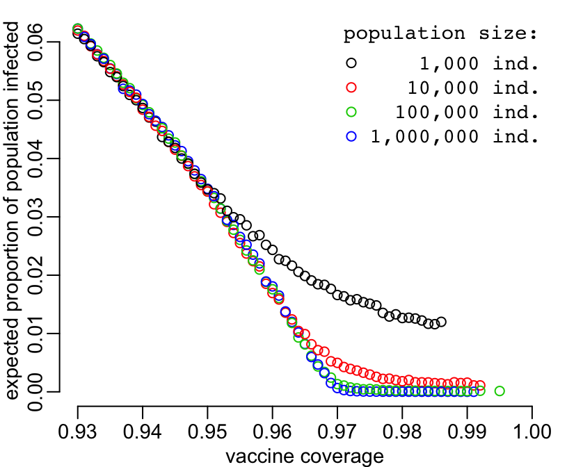

```r
four_sims2 <- dplyr::filter(four_sims, p >= .93)
plot(epi_size ~ p, four_sims2, xlab = "vaccine coverage",
     ylab = "expected proportion of population infected", col = four_sims2$sim)
op <- par(family = "mono")
legend("topright", legend = c("    1,000 ind.", "   10,000 ind.", "  100,000 ind.", "1,000,000 ind."),
       col = 1:4, pch = 1, bty = "n", title = "population size:")
```

```r
par(op)
```

The differences for the high vaccine coverage is an artefact of the chosen threshold on the number of 10 infected individuals chosen to define an epidemic. As such, populations of different sizes will have similar epidemic dynamics.

In consequence, we’ll use this data frame for our analyses. This provides a deterministic relationship between vaccine coverage and probability of epidemics in populations of arbitrary sizes.

```r
ref <- sim6 %>%
  dplyr::transmute(vacc_cov = p,
                   epi_proba = epi_proba,
                   epi_prop = mean_epi_size / 1e6)
```

which looks like this:

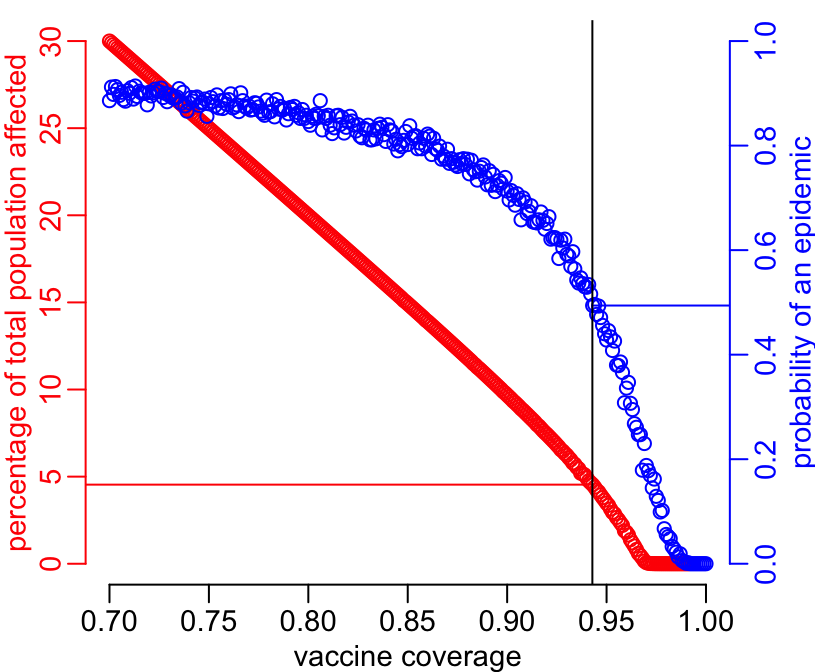

```r
ref2 <- dplyr::filter(ref, vacc_cov >= .7)
tmp2 <- tail(dplyr::filter(ref2, vacc_cov < round(pc, 3) + .001), 1)
plot((100 * epi_prop) ~ vacc_cov, ref2, xlab = "vaccine coverage",
     ylab = NA, col = col1, axes = FALSE)
axis(1)
axis(2, col = col1, col.axis = col1)
title(ylab = "percentage of total population affected", col.lab = col1)
segments(0, 100 * tmp2$epi_prop, pc, 100 * tmp2$epi_prop, col = col1)
par(new = TRUE)
plot(epi_proba ~ vacc_cov, ref2, ann = FALSE, col = col2, axes = FALSE, ylim = 0:1)
axis(4, col = col2, col.axis = col2)
mtext("probability of an epidemic", 4, 1.5, col = col2)
segments(pc, tmp2$epi_proba, 1.1, tmp2$epi_proba, col = col2)
abline(v = pc)
```

### Probability of epidemic and number of initial infectives

The probability of an epidemic will depend on the number of infected individuals introduced in the population: The following computes the probability of an epidemics over different vaccine coverages and different initial infective levels. Furthermore, in keeping with an already established assumption, an epidemic is defined as the total number of secondary being in excess of 10.

```r
epi_proba2 <- function(p = 1 - 1/17.5, I0 = 1, N = 1e6, n = 1000, t = 0.1,
                       threshold = 10, ...) {
  simulate <- function(x, y) seir(p = x, I0 = y, N = N, ...)

  f <- function(x, y) {
    R_size <- unlist(purrr::rerun(n, dplyr::last(simulate(x, y)$R)))
    epi_size <- R_size - round(x * (N - y))
    sel <- epi_size > threshold
    c(mean(sel))
  }

  df <- data.frame("p" = p,
                   do.call(cbind,
                           purrr::map(I0, function(y) unlist(purrr::map(p, function(x) f(x, y))))))
  colnames(df) <- c("p", unlist(purrr::map(seq(1, length(I0)), function(x) c(paste0("I", x)))))
  df
}
```

Let’s run this over a range of vaccine coverages and initial number of infectives.

```r
epi_probs <- epi_proba2(p = seq(0, 1, 0.001), I0 = seq(1, 10, 1), tf = 1000, n = 1000)
```

Let’s see how these epidemic probabilities compare to the approximate probabilities used in the first approximate model that is outlined in a section below. That is,
$$\begin{aligned}
\text{Approximate probability of an epidemic} = 1 - (1 - p(v))^{I_0}
\end{aligned}$$
where $p(v)$ is the probability of an epidemic starting from one infective in a population with vaccine coverage of $v\%$ and $I_0$ is the number of infectives introduced into the population.

```r
est_epi_probs <- data.frame(sim6$p, do.call(cbind, purrr::map(seq(1, 10, 1), function(x) (1 - (1 - sim6$epi_proba)^x))))
diff <- data.frame("p" = sim6$p, do.call(cbind, purrr::map(seq(1, 10), function(x) as.matrix(epi_probs)[,x] - est_epi_probs[, x])))
```

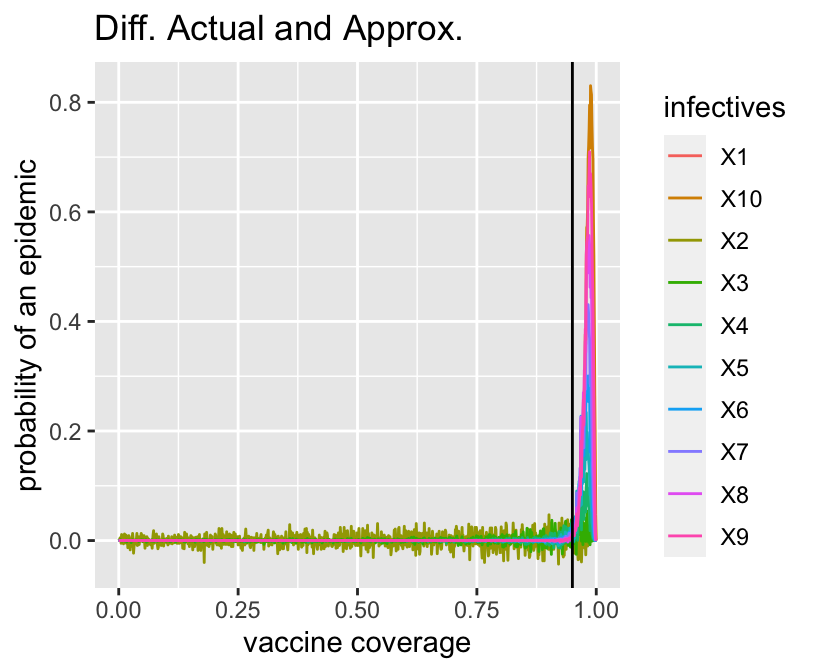

```r
diff %>% gather(key = infectives, value = probability, X1:X10)  %>%
  ggplot(aes(x = p, y = probability, color = infectives, group = infectives)) + geom_line() +
  labs(x = "vaccine coverage", y = "probability of an epidemic", title = "Diff. Actual and Approx.") +
  geom_vline(xintercept = 0.95)
```

## A Stochastic Population Network

### Two city stochastic SEIR model for measles epidemics (Rozhnova)

The number of individuals in the four classes belonging to city $j$ is denoted by $S_j, E_j, I_j$ and $R_j$ respetively. It is worth noting that the number of individuals belonging to any one city $N_j$ does not change with time. As such, the number of individuals belonging to city $j$ is given by $N_j = S_j + E_j + I_j + R_j$ for $j = 1, 2$. There are three types of transitions for each city.

1. Infected individual becoming infectious: For city j, this occurs at rate $\sigma E_j$. Result: $E_j \rightarrow E_j - 1$ and $I_j \rightarrow I_j + 1$.
2. Recovery of an infective individual: For city j, this occurs at rate $\gamma I_j$. Result: $R_j \rightarrow R_j + 1$ and $I_j \rightarrow I_j - 1$.

The infectious process introduces transmission via out-of-city commuters. Let a fraction $f_{jk}$ denote the residents of city $k$ that commute to city $j$ where $j, k = 1,2$. Intuitively, $f_{jk}$ defines the average fraction of time an individual from city $k$ spends in city $j$. As such, the number of individuals in city $j$ is $M_j = (1 - f_{kj})N_j + f_{jk}N_k$, where $j \neq k$. Consider a susceptible individuals from city 1. There are four types of infective interations:

- infective residents in city 1 infect susceptible residents in city 1: $\beta(1 - f_{21})S_1(1 - f_{21})I_1 / M_1$
- infective commuters from city 2 infect susceptible resident in city 1: $\beta(1 - f_{21})S_1 f_{12}I_2 / M_1$
- infective residents in city 2 infect susceptible commuters from city 1: $\beta f_{21}S_1 (1 - f_{12})I_2 / M_2$
- infective commuters from city 1 infect susceptible commuters from city 1 in city 2: $\beta f_{21} S_1 f_{21} I_1 / M_2$

where $\beta$ is the parameter for the overall rate of infection. A similar analysis can be made for the susceptible individuals from city 2.

3. Infection of a susceptible individual: For individual in city 1, this occurs at rate $\beta\left[c_{11} \frac{S_1 I_1}{N_1} + c_{12} \frac{S_1 I_2}{N_2}\right]$ and for individual in city 2, this occurs at rate $\beta\left[c_{21} \frac{S_2 I_1}{N_1} + c_{22} \frac{S_2 I_2}{N_2}\right]$.

where
$$\begin{aligned}
c_{11} & = \frac{(1 - f_{21})^2}{1 - f_{21} + f_{12}q} + \frac{f_{21}^2}{f_{21} + (1 - f_{12})q} \\
c_{12} & = \frac{(1 - f_{21})f_{12}q}{1 - f_{21} + f_{12}q} + \frac{f_{21}(1 - f_{12})q}{f_{21} + (1 - f_{12})q} \\
c_{21} & = \frac{(1 - f_{12}) f_{21}}{f_{21} + (1 - f_{12})q} + \frac{f_{12}(1 - f_{21})}{1 - f_{21} + f_{12}q} \\
c_{22} & = \frac{(1 - f_{12})^2q}{f_{21} + (1 - f_{12})q} + \frac{f_{12}^2 q}{1 - f_{21} + f_{12}q} \\
\end{aligned}$$
and $q = N_2 / N_1$.

Consider two populations/cities. City 1 has `N1` individuals, of which `I10` are infections, `p1` % are vaccinated and the rest are susceptible. City 2 has `N2` individuals, of which `I20` are infections, `p2` % are vaccinated and the rest are susceptible. For both populations, the disease spreads in the population with an infectious contact rate of `beta` / person / time unit. Infected individuals remain in a latency period of mean duration `1 / sigma` time units before they become infectious from which state they recover at the rate of `gamma` / time unit. The following function runs stochastic individual-based simulations of this model for a duration of `tf` time units, using the algorithm coded in the `f` function. The algorithm implements adaptive tau leaping to approximate the trajectory of a continuous-time stochastic process (the Gillespie stochastic simulation algorithm). This model incorporates demographic stochasticity, which is defined as population processes that are driven by the random nature of events at the level of the individual. Furthermore, we consider the SEIR model; that is, the host can be categorized as susceptible, infected but not yet infectious, infectious or recovered.

```r
seir2City <- function(N1 = 8e6, N2 = 1.5e6, I10 = 1, I20 = 1, p1 = 0, p2 = 0,
                      beta = 5, sigma = 1/7, gamma = 1/7, f21 = 0.01, f12 = 0.05,
                      tf = 100, f = adaptivetau::ssa.adaptivetau, ...) {
  q <- N2 / N1
  c11 <- (1 - f21)^2 / (1 - f21 + f12*q) + f21^2 / (f21 + (1 - f12)*q)
  c12 <- (1 - f21)*f12*q / (1 - f21 + f12*q) + f21*(1 - f12)*q / (f21 + (1 - f12)*q)
  c21 <- (1 - f12)*f21 / (f21 + (1 - f12)*q) + f12*(1 - f21) / (1 - f21 + f12*q)
  c22 <- (1 - f12)^2 * q / (f21 + (1 - f12)*q) + f12^2 * q / (1 - f21 + f12*q)
  vaccinated1 <- round(p1 * (N1 - 1))
  vaccinated2 <- round(p2 * (N2 - 1))
  x0 <- c(S1 = N1 - I10 - vaccinated1, E1 = 0, I1 = I10, R1 = vaccinated1,
          S2 = N2 - I20 - vaccinated2, E2 = 0, I2 = I20, R2 = vaccinated2)
  transitions <- list(c(S1 = -1, E1 = +1),  # infection
                      c(E1 = -1, I1 = +1),  # getting infectious
                      c(I1 = -1, R1 = +1),  # recovery
                      c(S2 = -1, E2 = +1),  # infection
                      c(E2 = -1, I2 = +1),  # getting infectious
                      c(I2 = -1, R2 = +1))  # recovery
  lvrates <- function(x, params, t) {
    rates1 <- with(c(x, params), c(beta * (c11 * S1 * I1 / N1 + c12 * S1 * I2 / N2),
                                   sigma * E1, gamma * I1))
    rates2 <- with(c(x, params), c(beta * (c21 * S2 * I1 / N1 + c22 * S2 * I2 / N2),
                                   sigma * E2, gamma * I2))
    c(rates1, rates2)
  }
  data.frame(f(x0, transitions, lvrates,
               list(beta = beta, sigma = sigma, gamma = gamma), tf = tf, ...))
}
```

#### Explorations of the two city model

For the following two-city explorations, we will consider a large city of 8 million people and a smaller provincial city of 1 million. Furthermore, we will assume that the number of people that travel from the large city to the small city is relatively small and fixed, whereas the number of people that travel from the small city to the large city is variable.

First, suppose that the large city has a relatively high vaccine coverage in comparison to the smaller city. We will explore how the epidemic dynamics in the large population change with increasing demographic coupling between the two cities. The following function computes the probability of an epidemic for the large city in a two-city model over different levels of coupling between the two cities. Note that will still define an epidemic as at least 10 secondary infections.

```r
epi_proba_mean_size3 <- function(N1 = 8e6, N2 = 1e6, I10 = 1, I20 = 1, p1 = 0.95, p2 = 0.75,
                                 f21 = 0.01, f12 = 0.01, n = 10000, t = 0.1, threshold = 10,
                                 nbcores = NULL, ...) {
  library(dplyr)
  if (is.null(nbcores)) nbcores <- parallel::detectCores() - 1
  simulate <- function(x) seir2City(N1 = N1, N2 = N2, I10 = I10, I20 = I20, p1 = p1, p2 = p2,
                                    f21 = f21, f12 = x,...)

  f <- function(x) {
    R_size <- unlist(purrr::rerun(n, dplyr::last(simulate(x)$R1)))
    epi_size <- R_size - round(p1 * (N1 - 1))
    sel <- epi_size > threshold
    c(epi_proba = mean(sel),
      mean_epi_size = mean(epi_size[sel]))
  }
  f12 %>%
    parallel::mclapply(f, mc.cores = nbcores) %>%
    purrr::map(~ t(.) %>% as.data.frame()) %>%
    purrr::map2(f12, ~ dplyr::mutate(.x, f12 = .y)) %>%
    dplyr::bind_rows() %>%
    dplyr::select(f12, dplyr::everything())
}
```

Let’s simulate this hypothetical two-city network.

```r
sim12 <- epi_proba_mean_size3(f12 = seq(0, 0.20, 0.01), f21 = 0.00001, tf = 1000)
```

Let’s see how the probability of an epidemic and the mean epidemic size given an epidemic occurs change with increasing coupling between the two cities.

```r
col1 <- "red"
col2 <- "blue"
plot(mean_epi_size ~ f12, sim12, xlab = "demographic coupling", ylab = NA,
     col = col1, axes = FALSE)
axis(1)
axis(2, col = col1, col.axis = col1)
title(ylab = "expected epidemic size", col.lab = col1)
par(new = TRUE)
plot(epi_proba ~ f12, sim12, ann = FALSE, col = col2, axes = FALSE)
axis(4, col = col2, col.axis = col2)
mtext("probability of an epidemic", 4, 1.5, col = col2)
```

[output not shown]

```r
epi_proba_mean_size4 <- function(N1 = 8e6, N2 = 1e6, I10 = 1, I20 = 1, p1 = 0.95, p2 = 0.75,
                                 f21 = 0.01, f12 = 0.1, n = 1000, t = 0.1, threshold = 10,
                                 nbcores = NULL, ...) {
  library(dplyr)
  if (is.null(nbcores)) nbcores <- parallel::detectCores() - 1
  simulate <- function(x) seir2City(N1 = N1, N2 = N2, I10 = I10, I20 = I20, p1 = p1, p2 = x,
                                    f21 = f21, f12 = f12,...)

  f <- function(x) {
    R_size <- unlist(purrr::rerun(n, dplyr::last(simulate(x)$R1)))
    epi_size <- R_size - round(p1 * (N1 - 1))
    sel <- epi_size > threshold
    c(epi_proba = mean(sel),
      mean_epi_size = mean(epi_size[sel]))
  }
  p2 %>%
    parallel::mclapply(f, mc.cores = nbcores) %>%
    purrr::map(~ t(.) %>% as.data.frame()) %>%
    purrr::map2(p2, ~ dplyr::mutate(.x, p2 = .y)) %>%
    dplyr::bind_rows() %>%
    dplyr::select(p2, dplyr::everything())
}
```

Let’s simulate this hypothetical two-city network.

```r
sim13 <- epi_proba_mean_size4(p2 = seq(0, 1, 0.01) , tf = 1000)
```

```r
col1 <- "red"
col2 <- "blue"
plot(mean_epi_size ~ p2, sim13, xlab = "vaccination coverage in smaller city", ylab = NA,
     col = col1, axes = FALSE)
axis(1)
axis(2, col = col1, col.axis = col1)
title(ylab = "expected epidemic size", col.lab = col1)
par(new = TRUE)
plot(epi_proba ~ p2, sim13, ann = FALSE, col = col2, axes = FALSE)
axis(4, col = col2, col.axis = col2)
mtext("probability of an epidemic", 4, 1.5, col = col2)
```

[output not shown]

### N city stochastic SEIR model for measles epidemics (Rozhnova)

Again, the number of individuals in the four classes belonging to city $j$ is denoted by $S_j, E_j, I_j$ and $R_j$ respetively. The number of individuals belonging to city $j$ is given by $N_j = S_j + E_j + I_j + R_j$ for $j \in \{1,2,\ldots,n\}$. There are three types of transitions for each city.

1. Infected individual becoming infectious: For city j, this occurs at rate $\sigma E_j$. Result: $E_j \rightarrow E_j - 1$ and $I_j \rightarrow I_j + 1$.
2. Recovery of an infective individual: For city j, this occurs at rate $\gamma I_j$. Result: $R_j \rightarrow R_j + 1$ and $I_j \rightarrow I_j - 1$.

The derivation of the rate of infection is analogous to that of the two city model. Let a fraction $f_{jk}$ denote the residents of city $k$ that commute to city $j$ where $j, k \in \{1,2,\ldots, n\}$. Intuitively, $f_{jk}$ defines the average fraction of time an individual from city $k$ spends in city $j$. To ease notation consider the quantity
$$\begin{aligned}
f_j = \sum_{k \neq j} f_{kj}
\end{aligned}$$
which denotes the fraction of residents of city $j$ that are in a different city at any given point in time. As such, the number of individuals in city $j$ is
$$\begin{aligned}
M_j = (1 - f_j) N_j + \sum_{k \neq j} f_{jk} N_k
\end{aligned}$$
Again, consider a susceptible individuals from city 1. There are four types of infective interations:

- infective residents in city 1 infect susceptible residents in city 1: $\beta(1 - f_1)S_1(1 - f_1)I_1 / M_1$
- infective commuters from city 2 infect susceptible resident in city 1: $\beta(1 - f_1)S_1 \sum_{j \neq 1} f_{1j} I_j / M_1$
- infective residents in city 2 infect susceptible commuters from city 1: $\beta \sum_{j \neq 1} (1 - f_j) I_j f_{j1} S_1 / M_j$
- infective commuters from city 1 infect susceptible commuters from city 1 in city 2: $\beta \sum_{j \neq 1} f_{j1} S_1 \sum_{k \neq j} f_{jk} I_k / M_j$

where $\beta$ is the parameter for the overall rate of infection. A similar analysis can be made for the susceptible individuals of all the remaining cities.

3. Infection of a susceptible individual: For individual in city $j$, this occurs at rate
   $$\begin{aligned}
   \beta \sum_{k=1}^n c_{jk} \frac{S_j I_k}{N_k}
   \end{aligned}$$
   where
   $$\begin{aligned}
   c_{jj} = \frac{(1 - f_j)^2 N_j}{\left[(1 - f_j)N_j + \sum_{m\neq j} f_{jm} N_m \right]} + \sum_{l \neq j} \frac{f_{lj}^2 N_j}{\left[(1 - f_l)N_l + \sum_{m \neq l} f_{lm} N_m\right]}
   \end{aligned}$$
   for $j = 1, \ldots, n$ and
   $$\begin{aligned}
   c_{jj} = \frac{(1 - f_j)f_{jk} N_k}{\left[(1 - f_j)N_j + \sum_{m\neq j} f_{jm} N_m \right]} + \frac{(1 - f_k)f_{kj} N_k}{\left[(1 - f_k)N_k + \sum_{m\neq k} f_{km} N_m \right]} + \sum_{l \neq j,k} \frac{f_{lj}f_{lk} N_k}{\left[(1 - f_l)N_l + \sum_{m \neq l} f_{lm} N_m\right]}
   \end{aligned}$$
   for $j, k = 1,\ldots,n$ and $j \neq k$.

The following function implements the above model. Consider `num` populations/cities. City j has `N[j]` individuals, of which `I[j]` are infections, `p[j]` % are vaccinated and the rest are susceptible. For all populations, the disease spreads in the population with an infectious contact rate of `beta` / person / time unit. Infected individuals remain in a latency period of mean duration `1 / sigma` time units before they become infectious from which state they recover at the rate of `gamma` / time unit. `f` is the demographic coupling matrix among the `n` cities where $f_{jj} = 1 - \sum_{k \neq j} f_{kj}$. The following function runs stochastic individual-based simulations of this model for a duration of `tf` time units, using the algorithm coded in the `f` function. The algorithm implements adaptive tau leaping to approximate the trajectory of a continuous-time stochastic process (the Gillespie stochastic simulation algorithm).

```r
seirNCity <- function(num = 2, N = c(8e6, 1.5e6), I0 = c(1,1), p = c(0, 0),
                      beta = 5, sigma = 1/7, gamma = 1/7,
                      fM = matrix(c(0.99, 0.01, 0.05, 0.95), nrow = 2, ncol = 2, byrow = FALSE),
                      tf = 100, f = adaptivetau::ssa.adaptivetau, ...) {

  # vector of initial values
  vaccinated <- unlist(purrr::map2(p, N, function(x, y) round(x * (y - 1))))
  x0 <- unlist(purrr::pmap(list(I0, vaccinated, N), function(x, y, z) c(z - x - y, 0, x, y)))
  names(x0) <- unlist(purrr::map(seq(1, num), function(x) c(paste0("S", x), paste0("E", x),
                                                   paste0("I", x), paste0("R", x))))

  # Transitions
  varNames1 <- unlist(purrr::map(seq(1, num), function(x) c(paste0("S", x), paste0("E", x),
                                                   paste0("I", x))))
  varNames2 <- unlist(purrr::map(seq(1, num), function(x) c(paste0("E", x), paste0("I", x),
                                                   paste0("R", x))))
  fTransitions <- function(x, y) {
    tmp <- c(-1, +1)
    names(tmp) <- c(x, y)
    tmp
  }
  transitions <- purrr::map2(varNames1, varNames2, fTransitions)

  # City commmuter coefficients.
  f2 <- function(j, k) {
    if (j == k) {
        return(fM[j,j]^2 * N[j] / (fM[j,k] * N[j] + sum((t(N * t(fM))[j,])[-j])) +
                 sum(unlist(purrr::map(seq(1:num)[-j],
                                       function(x) (fM[x,j]^2 * N[j] /
                                                      (fM[x,x] * N[x] + sum(((t(N * t(fM))[x,])[-x]))))))))
      }
      if (j != k) {
        return(fM[j,j] * fM[j,k] * N[k] / (fM[j,j] * N[j] + sum((t(N * t(fM))[j,])[-j])) +
                 fM[k,j] * fM[k,k] * N[k] / (fM[k,k] * N[k] + sum((t(N * t(fM))[k,])[-k])) +
                 sum(unlist(purrr::map(seq(1:num)[-c(j,k)],
                                       function(x) (fM[x,j] * fM[x,k] * N[k] /
                                                      (fM[x,x] * N[x] + sum((t(N * t(fM))[x,])[-x])))))))

      }
  }
  I <- iterpc(num, 2, ordered = TRUE, replace = TRUE)
  coeffs <- unlist(purrr::map2(t(getall(I))[1,], t(getall(I))[2,], f2))
  cMatrix <- matrix(coeffs, nrow = num, ncol = num, byrow = TRUE)

  # rate function.
  lvrates <- function(x, params, t){
    cityRates <- function(j) {
    infectionRate <-
      sum(unlist(purrr::map(seq(1, num),
                            function(k) cMatrix[j, k] * x[paste0("S", j)] * x[paste0("I", k)] / N[k])))
    with(c(x, params), c(beta * infectionRate, sigma * x[paste0("E", j)], gamma * x[paste0("I", j)]))
    }
    unlist(purrr::map(seq(1, num), cityRates))
  }

  # simulation
  data.frame(f(x0, transitions, lvrates,
               list(beta = beta, sigma = sigma, gamma = gamma), tf = tf, ...))
}
```

Let’s try the model over two cities.

```r
sim2City <- seirNCity(num = 2, N = c(1e6, 1e6),
                      p = c(0.95, 0.5), I0 = c(1, 1),
                      fM = matrix(c(0.098, 0.002, 0.1, 0.9),
                                 nrow = 2, ncol = 2, byrow = FALSE))
```

which gives,

```r
head(sim2City)
```

```
##         time    S1 E1 I1     R1     S2 E2 I2     R2
## 1 0.00000000 50000  0  1 949999 499999  0  1 500000
## 2 0.03315208 50000  0  1 949999 499998  1  1 500000
## 3 0.04831887 50000  0  1 949999 499997  2  1 500000
## 4 0.11097490 50000  0  1 949999 499996  3  1 500000
## 5 1.25501929 50000  0  1 949999 499996  3  0 500001
## 6 1.59759685 50000  0  1 949999 499996  2  1 500001
```

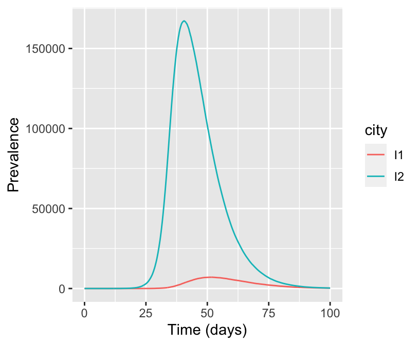

```r
library(dplyr)
sim2City %>% dplyr::select(time, I1, I2) %>%
  gather(key = city, value = number, I1, I2) %>%
  ggplot(aes(x = time, y = number, color = city, group = city)) + geom_line() +
  labs(x = "Time (days)", y = "Prevalence")
```

Now, let’s try the model over three cities.

```r
sim3City <- seirNCity(num = 3, N = c(1e6, 1e6, 1e6),
                      p = c(0.95, 0.5, 0.95), I0 = c(1, 0, 0),
                      fM = matrix(c(0.098, 0.001, 0.001, 0.1, 0.9, 0, 0.1, 0, 0.9),
                                 nrow = 3, ncol = 3, byrow = FALSE), tf = 150)
```

which gives

```r
head(sim3City)
```

```
##        time    S1 E1 I1     R1     S2 E2 I2     R2    S3 E3 I3     R3
## 1   0.00000 50000  0  1 949999 500000  0  0 500000 50001  0  0 949999
## 2  15.93211 50000  0  0 950000 500000  0  0 500000 50001  0  0 949999
## 3 150.00000 50000  0  0 950000 500000  0  0 500000 50001  0  0 949999
```

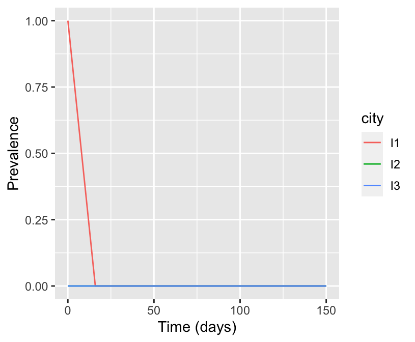

```r
library(dplyr)
sim3City %>% dplyr::select(time, I1, I2, I3) %>%
  gather(key = city, value = number, I1, I2, I3) %>%
  ggplot(aes(x = time, y = number, color = city, group = city)) + geom_line() +
  labs(x = "Time (days)", y = "Prevalence")
```

#### Explorations of the N-city model

Consider a large central city of 8 million people and two smaller satellite cities each with 1 million residents. Furthermore, suppose that the large city has a relatively high vaccine coverage in comparison to the two smaller cities. We will explore how the epidemic dynamics in the central change vary with different vaccine coverage levels in the satellite cities.

```r
epi_proba_mean_size5 <- function(num = 3, N = c(8e6, 1e6, 1e6), I0 = c(0, 1, 1),
                                 p = list(0.95, 0.5, 0.5),
                                 fM = matrix(c(0.098, 0.001, 0.001, 0.1, 0.9, 0, 0.1, 0, 0.9),
                                         nrow = 3, ncol = 3, byrow = FALSE),
                                 n = 1000, t = 0.1, threshold = 10,
                                 nbcores = NULL, ...) {
  library(dplyr)
  simulate <- function(x, y) seirNCity(num = num, N = N, I0 = I0, p = c(p[[1]], x, y),
                                    fM = fM, ...)

  f <- function(x, y) {
    R_size <- unlist(purrr::rerun(n, dplyr::last(simulate(x, y)$R1)))
    epi_size <- R_size - round(p[[1]] * (N[1] - 1))
    sel <- epi_size > threshold
    c(epi_proba = mean(sel),
      mean_epi_size = mean(epi_size[sel]))
  }
  purrr::map2(p[[2]], p[[3]], f) %>%
  purrr::map(~ t(.) %>% as.data.frame()) %>%
  dplyr::bind_rows() %>%
  dplyr::mutate(p2 = p[[2]], p3 = p[[3]]) %>%
  dplyr::select(p2, p3, dplyr::everything())
}
```

```r
sim14 <- epi_proba_mean_size5(num = 3, N = c(8e6, 1e6, 1e6), I0 = c(1, 1, 1),
                              p = list(0.95, seq(0, 1, 0.01), seq(0, 1, 0.01)),
                              f = matrix(c(0.098, 0.001, 0.001, 0.1, 0.9, 0, 0.1, 0, 0.9),
                                         nrow = 3, ncol = 3, byrow = FALSE),
                                    tf = 1000)
```

```r
col1 <- "red"
col2 <- "blue"
plot(mean_epi_size ~ p2, sim14, xlab = "vaccination coverage in satellite cities", ylab = NA,
     col = col1, axes = FALSE)
axis(1)
axis(2, col = col1, col.axis = col1)
title(ylab = "expected epidemic size", col.lab = col1)
par(new = TRUE)
plot(epi_proba ~ p2, sim14, ann = FALSE, col = col2, axes = FALSE)
axis(4, col = col2, col.axis = col2)
mtext("probability of an epidemic", 4, 1.5, col = col2)
```

[output not shown]

## A Deterministic/Stochastic Population Network: Model 1

### Deterministic SEIR model

Consider a population of `N` individuals with `Y0` initial infectives and `v`% vaccine coverage. The epidynamics of the population will be simulated by a deterministic SEIR model without demographic over a time frame `tf` days. The parameters are given by a transmission rate of `beta`, an average latency period of `1 / sigma` days and an average recovery period of `1 / gamma` days.
The system of differential equations that characterize this deterministic model are given by:
$$\begin{aligned}
\frac{dX}{dt} & = - \beta \frac{XY}{N} \\
\frac{dW}{dt} & = \beta \frac{XY}{N} - \sigma W \\
\frac{dY}{dt} & = \sigma W - \gamma Y \\
\frac{dR}{dt} & = \gamma Y \\
\end{aligned}$$
where $X, W, Y, Z$ are the number of susceptibles, infected but not infectious, infected and recovered individuals in the population.

```r
dseir <- function(N = 1e6, Y0 = 1, v = 0, beta = 5, sigma = 1/7, gamma = 1/7,
                 tf = 100, ...) {
  vaccinated <- round(v * (N - Y0))
  x0 <- c(X = N - Y0 - vaccinated, W = 0, Y = Y0, Z = vaccinated)
  parameters <- c(beta = beta, sigma = sigma, gamma = gamma)
  f <- function(t, state, parameters) {
    with(as.list(c(state, parameters)), {
      # rate of change
      dX = -beta * X * Y / N
      dW = beta * X * Y / N - sigma * W
      dY = sigma * W - gamma * Y
      dZ = gamma * Y

      # rate the rate of change
      list(c(dX, dW, dY, dZ))
      })
  }
  times <- seq(0, tf, by = 1)
  as.data.frame(ode(y = x0, times = times, func  = f,
                              parms = parameters))
}
```

Let’s run this deterministic SEIR with the default parameters.

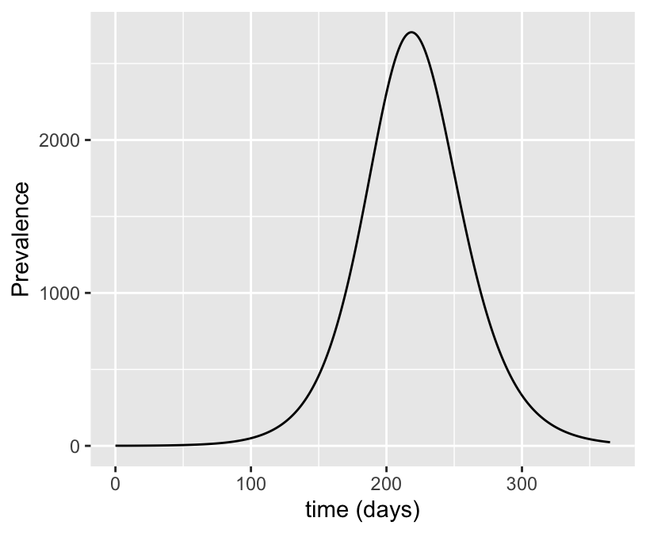

```r
dseir1 <- dseir(v = 0.95, tf = 365)
ggplot(dseir1, aes(x = time, y = Y)) + geom_line() +
  labs(x = "time (days)", y = "Prevalence")
```

Let’s see how this compares to the stochastic SEIR model with analogous parameters

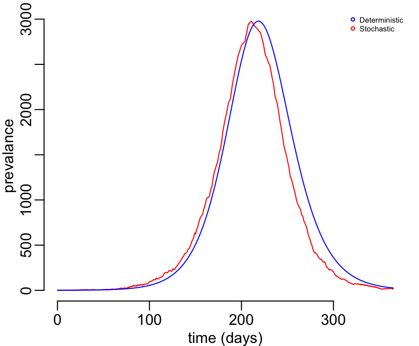

```r
set.seed(20)
sseir1 <- seir(N = 1e6, I0 = 1, p = 0.95, beta = 5, sigma = 1/7, gamma = 1/7, tf = 365)
plot(I ~ time, sseir1, xlab = "time (days)", ylab = "prevalance", col = "red", type = "l")
par(new = TRUE)
plot(Y ~ time, dseir1, ann = FALSE, axes = FALSE, col = "blue", type = "l")
legend("topright", legend = c("Deterministic", "Stochastic"), col = c("blue","red"), pch = 1,
       bty = "n",cex = 0.50)
```

The prevalence curves for the single population deterministic and stochastic models are consistent. Note that to make this statement more rigorous, we would have the simulate both models a number of times to derive an average behavior. Over numerous simulations, however, the above relationship holds so for brevity only one simulation is included.

### Numerical approximation of the relationship between probability of epidemic and vaccine coverage

We defined an epidemic as 10 or more secondary infections. We used this threshold to compute the probability that an epidemic occurs and the expected epidemic size in case there is an epidemic in a population of 1,000,000 individuals when a single infective is introduced.

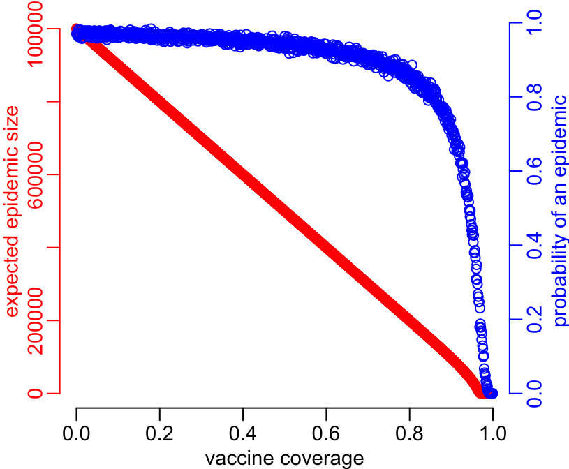

```r
col1 <- "red"
col2 <- "blue"
plot(mean_epi_size ~ p, sim6, xlab = "vaccine coverage",
     ylab = NA, col = col1, axes = FALSE)
axis(1)
axis(2, col = col1, col.axis = col1)
title(ylab = "expected epidemic size", col.lab = col1)
par(new = TRUE)
plot(epi_proba ~ p, sim6, ann = FALSE, col = col2, axes = FALSE)
axis(4, col = col2, col.axis = col2)
mtext("probability of an epidemic", 4, 1.5, col = col2)
```

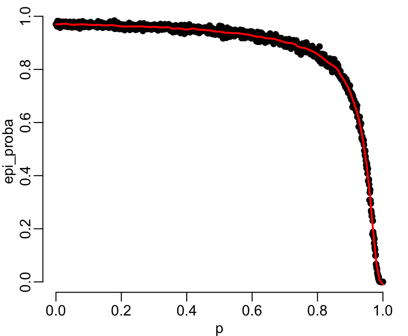

```r
y1 <- smooth.spline(x = sim6$p, y = sim6$epi_proba)
vaccineValues <- data.frame(p = seq(0, 1, 0.01))
fit <- predict(y1, x = vaccineValues)
plot(epi_proba ~ p, sim6, pch=16)
lines(fit$x$p, fit$y$p,lwd=2, col = "red", xlab = "vaccine coverage", ylab = "probability of an epidemic")
```

As expected, the natural spline is a good fit to the data points. This function, as given by the red curve, will be used to estimate the probability that a population has an epidemic on any given day when there is a single infective introduced into the population. Furthermore, it was illustrated in some of the single population explorations above that the probability of an epidemic across different vaccine coverages is largely independent of population size. As such, this function can be used for different population sizes without modification.

### Approximate N-city model

There are `n` cities in the network each with population size and vaccine coverage given by vectors `N` and `v` respectively. The number of initial infectives in each city is `Y0`. Furthermore, the strength of association between the two cities is given by $\rho_{21}$ and $\rho_{12}$, where $\rho_{ij}$ denotes the coupling from city $j$ to city $i$.

```r
nCityApprox <- function(n = 2, N = c(1e6, 1e6), v = c(0.95, 0.95), Y0 = c(1, 0),
                          rho = matrix(c(0.99, 0.01, 0.01, 0.99), nrow = 2, ncol = 2, byrow = FALSE),
                          tf = 365) {

 # Probability of epidemic for all populations starting with a single infective
 epi_prob <- predict(y1, x = data.frame(v))$y$v

 # Generate prevalence curves for infected populations
  f1 <- function(x, y) {
    if (x == 0)
      return (rep(0, tf+1))
    else
      return (dseir(N = N[y], Y0 = Y0[y], v = v[y], tf = tf)$Y)
  }
  I <- purrr::map2(Y0, seq(1, n), f1)
  I <- do.call(cbind, I)

  # Run the simulation over the specified time frame.
  for(t in 1:tf) {
    for(i in which(I[t, ] == 0)) {
      prob <- 1 - (1 - epi_prob[i])^(sum(I[t, ] * rho[, i]))
      if (runif(1, 0, 1) < prob) {
        I[, i] <- c(rep(0, t), dseir(N = N[i], Y0 = sum(I[t, ] * rho[, i]), v = v[i], tf = tf - t)$Y)
      }
    }
  }
  I <- as.data.frame(I) %>% mutate("time" = 1:(tf+1)) %>% select("time", dplyr::everything())
  colnames(I) <- c("time", unlist(purrr::map(seq(1, n), function(x) c(paste0("I", x)))))
  I
}
```

Let’s run this approximate model with the following parameters.

```r
sim15 <- nCityApprox(n = 2, N = c(1e6, 1e6), v = c(0.95, 0.5),
                     Y0 = c(0, 1), tf = 400,
                     rho = matrix(c(0.98, 0.02, 0.1, 0.9), nrow = 2, ncol = 2, byrow = FALSE))
```

```r
plot1 <- sim15 %>% gather(key = population, value = number, I1, I2) %>%
  ggplot(aes(x = time, y = number, color = population, group = population)) + geom_line() +
  labs(x = "Time (days)", y = "Prevalence", title = "Approximate Model")
```

Let’s compare this approximate model with exact stochastic model

```r
sim2City <- seirNCity(num = 2, N = c(1e6, 1e6),
                      p = c(0.95, 0.5), I0 = c(0, 1),
                      fM = matrix(c(0.098, 0.02, 0.1, 0.9),
                                 nrow = 2, ncol = 2, byrow = FALSE))
```

```r
plot2 <- sim2City %>% dplyr::select(time, I1, I2) %>%
  gather(key = population, value = number, I1, I2) %>%
  ggplot(aes(x = time, y = number, color = population, group = population)) + geom_line() +
  labs(x = "Time (days)", y = "Prevalence", title = "Exact Model")
```

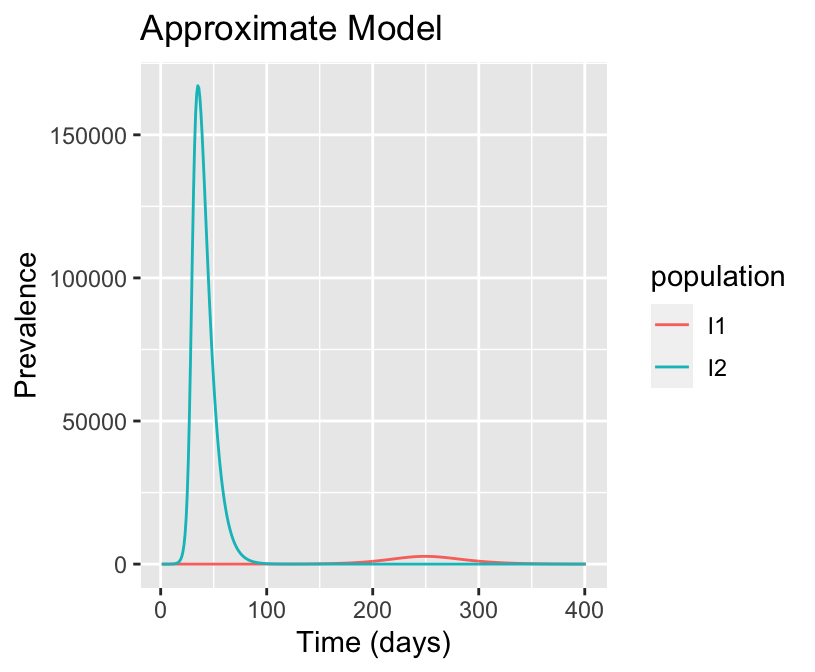

```r
plot1
```

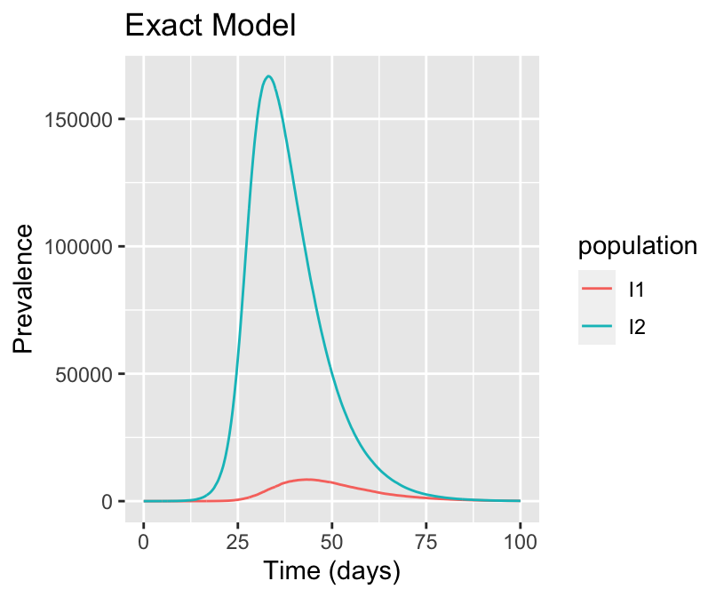

```r
plot2
```

For completeness, let’s consider a slightly more complex model with three populations.

```r
sim16 <- nCityApprox(n = 3, N = c(1e6, 1e6, 1e6),
                       v = c(0.95, 0.5, 0.95), Y0 = c(0, 1, 0),
                       rho = matrix(c(0.998, 0.001, 0.001, 0.1, 0.9, 0, 0.1, 0, 0.9),
                                 nrow = 3, ncol = 3, byrow = FALSE), tf = 700)
```

```r
plot3 <- sim16 %>% gather(key = population, value = number, I1, I2, I3) %>%
  ggplot(aes(x = time, y = number, color = population, group = population)) +
  geom_line() + labs(x = "Time (days)", y = "Prevalence", title = "Approximate Model") +
  xlim(0, 400)
```

Let’s compare this approximate model with exact stochastic model.

```r
sim3City <- seirNCity(num = 3, N = c(1e6, 1e6, 1e6),
                      p = c(0.95, 0.5, 0.95), I0 = c(0, 1, 0),
                      fM = matrix(c(0.998, 0.001, 0.001, 0.1, 0.9, 0, 0.1, 0, 0.9),
                                 nrow = 3, ncol = 3, byrow = FALSE), tf = 150)
```

```r
plot4 <- sim3City %>% dplyr::select(time, I1, I2, I3) %>%
  gather(key = population, value = number, I1, I2, I3) %>%
  ggplot(aes(x = time, y = number, color = population, group = population)) +
  geom_line() + labs(x = "Time (days)", y = "Prevalence", title = "Exact Model")
```

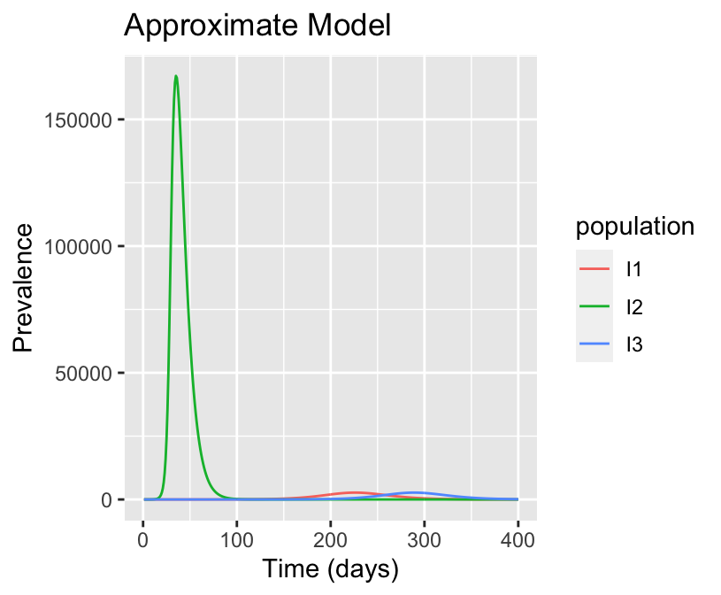

```r
plot3
```

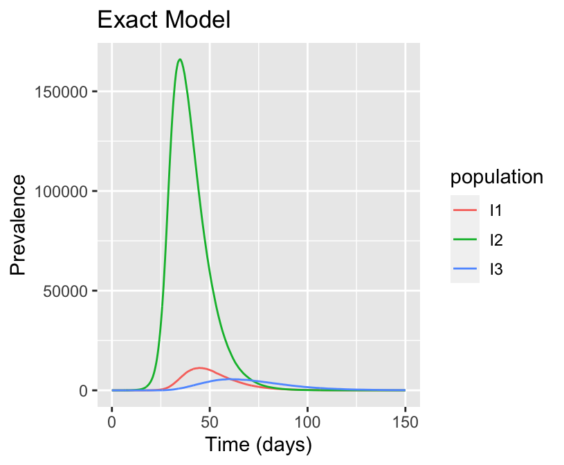

```r
plot4
```

There are also noticiable lags in the approximate model compared to the exact stochastic model.

## Second Approximation of the Population Network

The following approximation of the exact stochastic model attempts to account for the lag effects that were observed in the first approximate model by deterministically coupling populations that are experiencing epidemics. Rozhnova’s coupling constants are also employed to account for all possible modes of transmission between neighboring populations.

### Two population model (hard coded)

The epidynamics of the two coupled populations will be simulated by a deterministic SEIR metapopulation model without demographic over a time frame tf days. The parameters are given by a transmission rate of `beta`, an average latency period of `1 / sigma` days and an average recovery period of `1 / gamma` days. The system of differential equations that characterize this deterministic model are given by:
$$\begin{aligned}
\frac{dX_1}{dt} & = - \beta \left(c_{11} \frac{X_1 Y_1}{N_1} + c_{12} \frac{X_1 Y_2}{N_2} \right) \\
\frac{dW_1}{dt} & = \beta \left(c_{11} \frac{X_1 Y_1}{N_1} + c_{12} \frac{X_1 Y_2}{N_2} \right) - \sigma W_1 \\
\frac{dY_1}{dt} & = \sigma W_1 - \gamma Y_1 \\
\frac{dR_1}{dt} & = \gamma Y_1 \\
\frac{dX_2}{dt} & = - \beta \left(c_{21} \frac{X_2 Y_1}{N_1} + c_{22} \frac{X_2 Y_2}{N_2} \right) \\
\frac{dW_2}{dt} & = \beta \left(c_{11} \frac{X_2 Y_1}{N_1} + c_{12} \frac{X_2 Y_2}{N_2} \right) - \sigma W_2 \\
\frac{dY_2}{dt} & = \sigma W_2 - \gamma Y_2 \\
\frac{dR_2}{dt} & = \gamma Y_2 \\
\end{aligned}$$
where $X, W, Y, Z$ are the number of susceptible, infected but not infectious, infected and recovered individuals in the population respectively. The coupling coefficients are given by the matrix `c` and are the same as those in the exact stochastic model.

Computes the epidynamics of two populations over `tf` days with a disease parametetrised by a `beta` transmission rate per capita, a latency period of `1 / sigma` days and a recovery period of `1 / gamma` days. Furthermore, each population is initialized with `X0` susceptibles, `W0` infected but not infectious individuals, `Y0` infectives and `Z0` recovered individuals. The populations are coupled according to the 2-by-2 matrix `cMatrix`. It returns a list of length 2 with each element a dataframe with columns `time`, `X`, `W`, `Y`, `Z` that describe the dynamics of the epidemic over time. Note that the pre-computed coupling matrix must be provided; it will not be computed by the function itself.

```r
dseir2 <- function(X0 = c(1e6, 1e6), W0 = c(0, 0), Y0 = c(1, 1), Z0 = c(0, 0),
                   beta = 5, sigma = 1/7, gamma = 1/7,
                   cMatrix, tf = 100, ...) {

  # Initialization of variables
  N <- c(X0[1] + W0[1] + Y0[1] + Z0[1], X0[2] + W0[2] + Y0[2] + Z0[2])
  x0 <- c(X1 = X0[1], W1 = W0[1], Y1 = Y0[1], Z1 = Z0[1],
          X2 = X0[2], W2 = W0[2], Y2 = Y0[2], Z2 = Z0[2])

  # Parameter vector
  parameters <- c(beta = beta, sigma = sigma, gamma = gamma, N = N, cMatrix = cMatrix)

  # Returns the set of differential rate functions.
  f <- function(t, state, parameters) {
    with(as.list(c(state, parameters)), {
      # rate of change
      dX1 = - beta * (cMatrix[1,1] * X1 * Y1 / N[1] + cMatrix[1,2] * X1 * Y2 / N[2])
      dW1 = beta * (cMatrix[1,1] * X1 * Y1 / N[1] + cMatrix[1,2] * X1 * Y2 / N[2]) - sigma * W1
      dY1 = sigma * W1 - gamma * Y1
      dZ1 = gamma * Y1
      dX2 = - beta * (cMatrix[2,1] * X2 * Y1 / N[1] + cMatrix[2,2] * X2 * Y2 / N[2])
      dW2 = beta * (cMatrix[2,1] * X2 * Y1 / N[1] + cMatrix[2,2] * X2 * Y2 / N[2]) - sigma * W2
      dY2 = sigma * W2 - gamma * Y2
      dZ2 = gamma * Y2
      list(c(dX1, dW1, dY1, dZ1, dX2, dW2, dY2, dZ2))
      })
  }

  # Numerically solve the system of differential equations over time frame tf
  df <- as.data.frame(ode(y = x0, times = seq(0, tf, by = 1), func  = f, parms = parameters))

  # Reorganization of output
  df1 <- df %>% select(time, X1, W1, Y1, Z1)
  colnames(df1) <- c("time", "X", "W", "Y", "Z")
  df2 <- df %>% select(time, X2, W2, Y2, Z2)
  colnames(df2) <- c("time", "X", "W", "Y", "Z")
  return(list(df1, df2))
}
```

The following function implements a two-population stochastic/deterministic version of a SEIR metapopulation model over a time frame if `tf` days. The population size, vaccine coverage and initial number of infectives of each population is given by `N` `v`, `Y0` respectively. The transmission rate `beta`, the average latency period `1 / sigma` and the average recovery period `1 / gamma` are the same for all populations. The commuter coefficients among the populations are given by the matrix `fM`.

```r
TwoCityApprox2 <- function(n = 2, N = c(1e6, 1e6), v = c(0.95, 0.5), Y0 = c(1, 0),
                          fM = matrix(c(0.98, 0.02, 0.1, 0.9), nrow = 2, ncol = 2, byrow = FALSE),
                          tf = 365) {

 # Probability of epidemic for all populations starting with a single infective
 epi_prob <- predict(y1, x = data.frame(v))$y$v

 # Generate prevalence curves for infected populations
  f1 <- function(x, y) {
    if (x == 0)
      return (data.frame(time = seq(0, tf), X = rep(0, tf+1), W = rep(0, tf+1),
                         Y = rep(0, tf+1), Z = rep(0, tf+1)))
    else
      return (dseir(N = N[y], Y0 = Y0[y], v = v[y], tf = tf))
  }
  P <- purrr::map2(Y0, seq(1, n), f1)
  I <- do.call(cbind, purrr::map(P, function(x) x$Y))

 # Calculation of coupling coefficients
  q <- N[2]/N[1]
  c11 <- (1 - fM[2,1])^2 / (1 - fM[2,1] + fM[1,2]*q) +
    fM[2,1]^2 / (fM[2,1] + (1 - fM[1,2])*q)
  c12 <- (1 - fM[2,1])*fM[1,2]*q / (1 - fM[2,1] + fM[1,2]*q) +
    fM[2,1]*(1 - fM[1,2])*q / (fM[2,1] + (1 - fM[1,2])*q)
  c21 <- (1 - fM[1,2])*fM[2,1] / (fM[2,1] + (1 - fM[1,2])*q) +
    fM[1,2]*(1 - fM[2,1]) / (1 - fM[2,1] + fM[1,2]*q)
  c22 <- (1 - fM[1,2])^2 * q / (fM[2,1] + (1 - fM[1,2])*q) +
    fM[1,2]^2 * q / (1 - fM[2,1] + fM[1,2]*q)
  cMatrix <- matrix(c(c11, c12, c21, c22), nrow = n, ncol = n, byrow = TRUE)

  # Run the simulation over the specified time frame
  for (t in 1:tf) {
    for (i in which(I[t, ] == 0)) {
      prob <- 1 - (1 - epi_prob[i])^(sum(I[t, ] * cMatrix[i, ])) # probability of epidemic
      if (runif(1, 0, 1) < prob) {
        oldEpis <- which(I[t, ] != 0) # number of existing epidemics
        noEpis <- which(I[t, ] == 0)[which(I[t, ] == 0) != i]

        # modified coupling matrix with only pops. with epidemics
        if (length(which(I[t, ] == 0)) > 1) {
          newC <- cMatrix[-noEpis, ]
          newC <- newC[, -noEpis]
        }
        else newC <- cMatrix

        # Organize initial values for the deterministic metapopulation model
        inf <- sum(I[t, ] * cMatrix[i, ])
        vac <- round(v[i] * (N[i] - inf))
        oIni <- do.call(rbind, lapply(P, function(p) {
          return(c(p$X[t], p$W[t], p$Y[t], p$Z[t]))})[oldEpis])
        pos <- length(oldEpis[oldEpis < i]) + 1 # position of newly started epi. pop.

        # Simulate the deterministic metapopulation model
        Padd <- dseir2(X0 = insert(oIni[, 1], pos, N[i] - inf - vac),
                       Y0 = insert(oIni[, 3], pos, inf),
                       W0 = insert(oIni[, 2], pos, 0), Z0 = insert(oIni[, 4], pos, vac),
                       cMatrix = newC, tf = tf - t)

        # Update the dynamics of each population
        newEpis <- insert(oldEpis, pos, i)
        cutP <- purrr::map(newEpis, function(x) P[[x]][ !(P[[x]]$time %in% seq(t, tf+1)), ])
        Padd <- purrr::map(1:length(newEpis), function(x) mutate(Padd[[x]], time = seq(t, tf)))
        P[newEpis] <- purrr::map(1:length(newEpis), function(x) dplyr::bind_rows(cutP[[x]], Padd[[x]]))
        I <- do.call(cbind, purrr::map(P, function(x) x$Y))
      }
    }
  }
  df <- as.data.frame(cbind(I, time = P[[1]]$time))
  varNames <- unlist(purrr::map(seq(1, n), function(x) paste0("Y", x)))
  colnames(df) <- c(varNames, "time")
  return(df %>% dplyr::select(time, dplyr::everything()))
}
```

Let’s see how this approximate two-city model compares with the stochastic two-city model.

```r
sim20 <- TwoCityApprox2(n = 2, N = c(1e6, 1e6), v = c(0.5, 0.95), Y0 = c(1, 0), tf = 365,
                       fM = matrix(c(0.9, 0.1, 0.02, 0.98), nrow = 2, ncol = 2, byrow = FALSE))
```

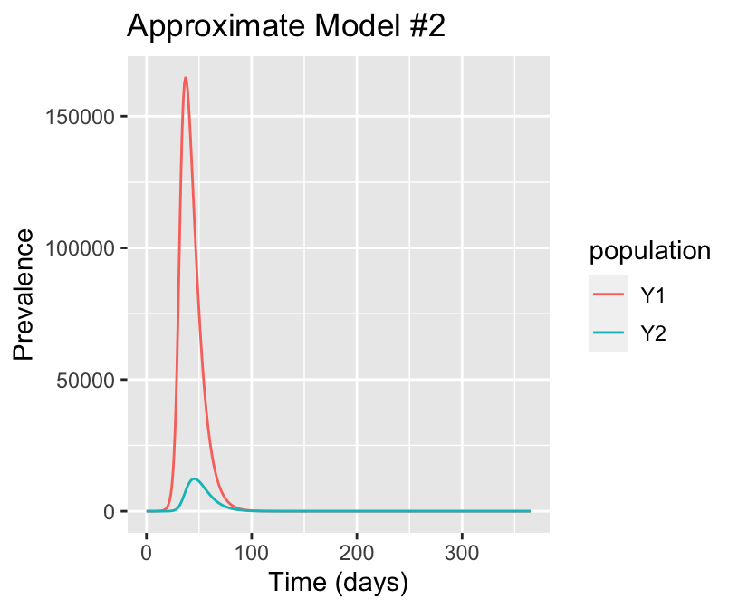

```r
sim20 %>% dplyr::select(time, Y1, Y2) %>%
  gather(key = population, value = number, Y1, Y2) %>%
  ggplot(aes(x = time, y = number, color = population, group = population)) +
  geom_line() + labs(x = "Time (days)", y = "Prevalence", title = "Approximate Model #2")
```

```r
sim2City <- seirNCity(num = 2, N = c(1e6, 1e6),
                      p = c(0.5, 0.95), I0 = c(1, 0),
                      fM = matrix(c(0.9, 0.1, 0.02, 0.98),
                                 nrow = 2, ncol = 2, byrow = FALSE), tf = 365)
```

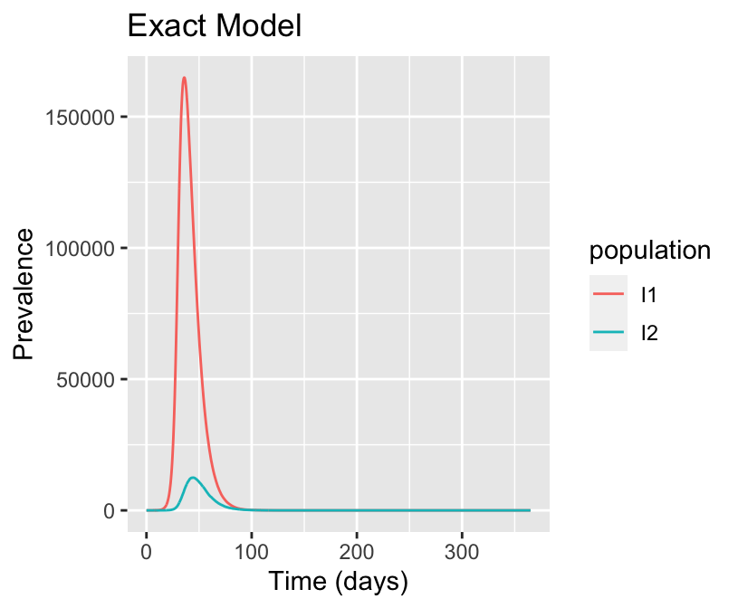

```r
sim2City %>% dplyr::select(time, I1, I2) %>%
  gather(key = population, value = number, I1, I2) %>%
  ggplot(aes(x = time, y = number, color = population, group = population)) + geom_line() +
  labs(x = "Time (days)", y = "Prevalence", title = "Exact Model")
```

The approximate deterministic/stochastic model is consistent with the stochastic model.

Let’s calculate the average time until the peak of the epidemic in population 1 and population 2 in both model. This will also serve as an opportunity to compare the running times of each of the models.

```r
library(timeR)
f1 <- function(n = 2, N = c(1e6, 1e6), v = c(0.5, 0.95), Y0 = c(1,0), tf = 365,
                        fM = matrix(c(0.9, 0.1, 0.02, 0.98), nrow = 2, ncol = 2, byrow = FALSE)) {
  df <- TwoCityApprox2(n = n, N = N, v = v, Y0 = Y0, tf = tf, fM = fM)
  c(df[which.max(df$Y1), 1], df[which.max(df$Y2), 1])
}

f2 <- function(num = 2, N = c(1e6, 1e6), p = c(0.5, 0.95), I0 = c(1,0),
               fM = matrix(c(0.9, 0.1, 0.02, 0.098), nrow = 2, ncol = 2, byrow = FALSE), tf = 365) {
  df <- seirNCity(num = num, N = N, p = p, I0 = I0, fM = fM)
  c(df[which.max(df$I1), 1], df[which.max(df$I2), 1])
}

timer <- createTimer(FALSE)
n <- 1000
timer$start("Deterministic Model")
approxModel <- colMeans(do.call(rbind, purrr::rerun(n, f1())))
timer$stop("Deterministic Model")
timer$start("Stochastic Model")
test <- do.call(rbind, purrr::rerun(n, f2()))
exactModel <- colMeans(do.call(rbind, purrr::rerun(n, f2())))
timer$stop("Stochastic Model")
```

```r
data.frame("Population 1 Peak" = approxModel[1], "Population 2 Peak" = approxModel[2])
```

```
##   Population.1.Peak Population.2.Peak
## 1            37.062            45.291
```

```r
data.frame("Population 1 Peak" = exactModel[1], "Population 2 Peak" = exactModel[2])
```

```
##   Population.1.Peak Population.2.Peak
## 1          34.81433          44.27125
```

```r
timer
```

```
## Your Table is:
##                 event               start                 end timeElapsed comment
## 1 Deterministic Model 2020-06-17 12:22:41 2020-06-17 12:24:33         112    <NA>
## 2    Stochastic Model 2020-06-17 12:24:33 2020-06-17 12:33:48         555    <NA>
```

The times of the epidemic peaks in both models are generally consistent. Furthermore, based on this very preliminary analysis the approximate model is about 5 times faster than the approximate model.

### N population model

Computes the epidynamics of `n` populations over `tf` days with a disease parameterised by a `beta` transmission rate per capita, a latency period of `1 / sigma` days and a recovery period of `1 / gamma` days. Furthermore, each population is initialized with `X0` susceptibles, `W0` infected but not infectious individuals, `Y0` infectives and `Z0` recovered individuals. The populations are coupled according to the `n`-by-`n` matrix `cMatrix`. It returns a list of length `n` with each element a dataframe with columns `time`, `X`, `W`, `Y`, `Z` that describe the dynamics of the epidemic over time. Note that the list is ordered according to the ordering of the populations when inputted as arguments. Note also that the pre-computed coupling matrix must be provided; it will not be computed by the function itself.

```r
dseirN <- function(n = 3, X0 = c(1e6, 1e6, 1e6), W0 = c(0, 0, 0), Y0 = c(1, 0, 0), Z0 = c(0, 0, 0),
                   beta = 5, sigma = 1/7, gamma = 1/7, cMatrix,
                   tf = 100, ...) {
  # Initialization of variables
  N <- colSums(rbind(X0, W0, Y0, Z0), na.rm=TRUE)
  varNames <- purrr::map(seq(1, n), function(x) c(paste0("X", x),paste0("W", x),paste0("Y", x),paste0("Z", x)))
  x0 <- unlist(purrr::map(seq(1, n), function(x) {
    tmp <- c(X0[x], W0[x], Y0[x], Z0[x]); names(tmp) <- varNames[[x]]; tmp}))

  # Parameter vector
  parameters <- c(beta = beta, sigma = sigma, gamma = gamma, N = N, cMatrix = cMatrix)

  # Returns the set of differential rate functions
  f <- function(t, state, parameters) {
    with(as.list(c(state, parameters)), {
      cityRates <- function(j) {
        infectionRate <-
          sum(unlist(purrr::map(seq(1, n),
                                function(k) cMatrix[j, k] * state[paste0("X", j)] *
                                  state[paste0("Y", k)] / N[k])))
        c(-beta * infectionRate, beta * infectionRate - sigma * state[paste0("W", j)],
          sigma * state[paste0("W", j)] - gamma * state[paste0("Y", j)], gamma * state[paste0("Y", j)])
    }
    list(unlist(purrr::map(seq(1, n), cityRates)))
    })
  }

  # Numerically solves the set of differential equation over time frame tf
  df <- as.data.frame(ode(y = x0, times = seq(0, tf, by = 1), func  = f, parms = parameters))

  # Reorganization of output
  return(purrr::map(seq(1, n), function(x) {
    tmp <- df %>% select(time, varNames[[x]]); colnames(tmp) <- c("time", "X", "W", "Y", "Z"); tmp}))
}
```

The following function computes and returns the coupling matrix for `n` populations each with population size `N` and commuter coefficients given by the matrix `fM`.

```r
generate_coupling_matrix <- function(n = 3, N = c(1e6, 1e6, 1e6),
                                     fM = matrix(c(0.098, 0.001, 0.001, 0.47, 0.53, 0, 0.01, 0, 0.09),
                                                 nrow = 3, ncol = 3, byrow = FALSE)) {
  f <- function(j, k) {
    if (j == k) {
      return(fM[j,j]^2 * N[j] / (fM[j,k] * N[j] + sum((t(N * t(fM))[j,])[-j])) +
               sum(unlist(purrr::map(seq(1:n)[-j],
                                     function(x) (fM[x,j]^2 * N[j] /
                                                    (fM[x,x] * N[x] + sum(((t(N * t(fM))[x,])[-x]))))))))
      }
    if (j != k) {
      return(fM[j,j] * fM[j,k] * N[k] / (fM[j,j] * N[j] + sum((t(N * t(fM))[j,])[-j])) +
               fM[k,j] * fM[k,k] * N[k] / (fM[k,k] * N[k] + sum((t(N * t(fM))[k,])[-k])) +
               sum(unlist(purrr::map(seq(1:n)[-c(j,k)],
                                     function(x) (fM[x,j] * fM[x,k] * N[k] /
                                                    (fM[x,x] * N[x] + sum((t(N * t(fM))[x,])[-x])))))))
    }
  }
  myIter <- iterpc(n, 2, ordered = TRUE, replace = TRUE)
  coeffs <- unlist(purrr::map2(t(getall(myIter))[1,], t(getall(myIter))[2,], f))
  cMatrix <- matrix(coeffs, nrow = n, ncol = n, byrow = TRUE)
  return(cMatrix)
}
```

Let’s try the function `deirN()` with the default parameters. Note that a precomputed coupling matrix must be provided to the function.

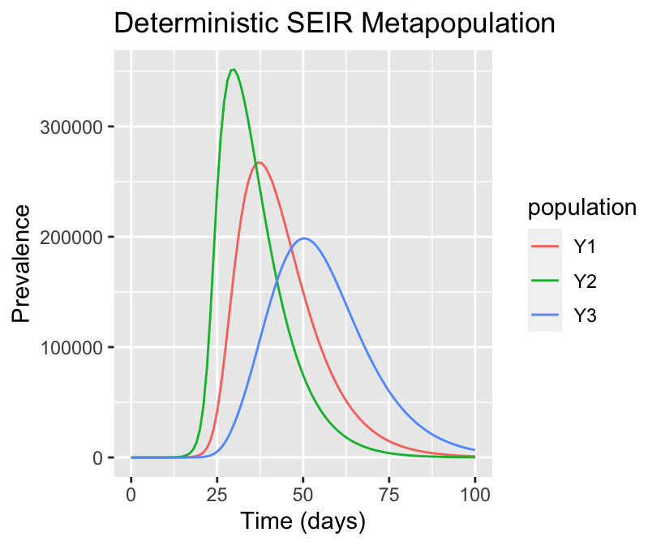

```r
# Compute the coupling matrix
N <- c(1e6+1, 1e6, 1e6)
fM <- matrix(c(0.098, 0.001, 0.001, 0.47, 0.53, 0, 0.01, 0, 0.09), nrow = 3, ncol = 3, byrow = FALSE)
cMatrix <- generate_coupling_matrix(n = 3, N  = N, fM = fM)

# Solve the deterministic metapopulation model
sim21 <- dseirN(cMatrix = cMatrix)
df <- as.data.frame(do.call(cbind, purrr::map(sim21, function(x) x$Y)))
colnames(df) <- c("Y1", "Y2", "Y3")
df <- df %>% dplyr::mutate("time" = sim21[[1]]$time) %>% select(time, dplyr::everything())

# Plot the results
df %>% gather(key = population, value = number, Y1, Y2, Y3) %>%
  ggplot(aes(x = time, y = number, color = population, group = population)) + geom_line() +
  labs(x = "Time (days)", y = "Prevalence", title = "Deterministic SEIR Metapopulation")
```

The following function implements a `n`-population stochastic/deterministic version of a SEIR metapopulation model over a time frame if `tf` days. The population size, vaccine coverage and initial number of infectives of each population is given by `N` `v`, `Y0` respectively. The transmission rate `beta`, the average latency period `1 / sigma` and the average recovery period `1 / gamma` are the same for all populations. The commuter coefficients among the populations are given by the matrix `fM`.

```r
nCityApprox2 <- function(n = 2, N = c(1e6, 1e6), v = c(0.95, 0.5), Y0 = c(1, 0),
                         beta = 5, sigma = 1/7, gamma = 1/7,
                         fM = matrix(c(0.98, 0.02, 0.1, 0.9), nrow = 2, ncol = 2, byrow = FALSE),
                         tf = 365) {

 # Probability of epidemic for all populations starting with a single infective
 epi_prob <- predict(y1, x = data.frame(v))$y$v

 # Calculation of coupling coefficients
 cMatrix <- generate_coupling_matrix(n = n, N = N, fM = fM)


 # Generate prevalence curves for initial infected populations
 P <- purrr::map(seq(1, n), function(x)
    return(data.frame(time = seq(0, tf), X = rep(0, tf+1), W = rep(0, tf+1),
                      Y = rep(0, tf+1), Z = rep(0, tf+1))))
 currentEpis <- which(Y0 > 0)
 if (length(currentEpis) > 1) {
   z <- unlist(purrr::map(currentEpis, function(x) round(v[x] * (N[x] - Y0[x]))))
   y <- Y0[currentEpis]
   x <- N[currentEpis] - Y0[currentEpis] - z[1:length(currentEpis)]
   w <- rep(0, length(currentEpis))
   newC <- cMatrix[currentEpis, ]
   newC <- newC[, currentEpis]
   epiP <- dseirN(n = length(currentEpis), X0 = x, Y0 = y, W0 = w, Z0 = z, tf = tf,
                  cMatrix = newC)
 }
 else
   epiP <- list(dseir(N = N[currentEpis], Y0 = Y0[currentEpis], v = v[currentEpis], tf = tf))
 P[currentEpis] <- epiP
 I <- do.call(cbind, purrr::map(P, function(x) x$Y))

 # Run the simulation over the specified time frame
 for (t in 1:tf) {
   for (i in which(I[t, ] == 0)) {
     prob <- 1 - (1 - epi_prob[i])^(sum(I[t, ] * cMatrix[i, ])) # probability of epidemic
     if (runif(1, 0, 1) < prob) {
       oldEpis <- which(I[t, ] != 0) # number of existing epidemics
       noEpis <- which(I[t, ] == 0)[which(I[t, ] == 0) != i]

       # modified coupling matrix with only pops. with epidemics
       if (length(which(I[t, ] == 0)) > 1) {newC <- cMatrix[-noEpis, ]; newC <- newC[, -noEpis]}
       else newC <- cMatrix

       # Organize initial values for the deterministic metapopulation model
       inf <- sum(I[t, ] * cMatrix[i, ])
       vac <- round(v[i] * (N[i] - inf))
       oIni <- do.call(rbind, lapply(P, function(p) {
          return(c(p$X[t], p$W[t], p$Y[t], p$Z[t]))})[oldEpis])
       pos <- length(oldEpis[oldEpis < i]) + 1

       # Simulate the deterministic metapopulation model
       Padd <- dseirN(n = length(oldEpis) + 1,
                      X0 = insert(oIni[, 1], pos, N[i] - inf - vac),
                      Y0 = insert(oIni[, 3], pos, inf),
                      W0 = insert(oIni[, 2], pos, 0), Z0 = insert(oIni[, 4], pos, vac),
                      cMatrix = newC, tf = tf - t)

       # Update the dynamics of each population
       newEpis <- insert(oldEpis, pos, i)
       cutP <- purrr::map(newEpis, function(x) P[[x]][ !(P[[x]]$time %in% seq(t, tf+1)), ])
       Padd <- lapply(Padd, function(x) mutate(x, time = seq(t, tf)))
       P[newEpis] <- purrr::map2(cutP, Padd, function(x, y) dplyr::bind_rows(x, y))
       I <- do.call(cbind, purrr::map(P, function(x) x$Y))
      }
    }
 }

 df <- as.data.frame(cbind(I, time = P[[1]]$time))
 varNames <- unlist(purrr::map(seq(1, n), function(x) paste0("Y", x)))
 colnames(df) <- c(varNames, "time")
 return(df %>% dplyr::select(time, dplyr::everything()))
}
```

Let’s see how this approximate n-city model compares with the stochastic two-city model.

```r
sim20 <- nCityApprox2(n = 2, N = c(1e6, 1e6), v = c(0.5, 0.95), Y0 = c(1, 0), tf = 100,
                       fM = matrix(c(0.9, 0.1, 0.02, 0.98), nrow = 2, ncol = 2, byrow = FALSE))
```

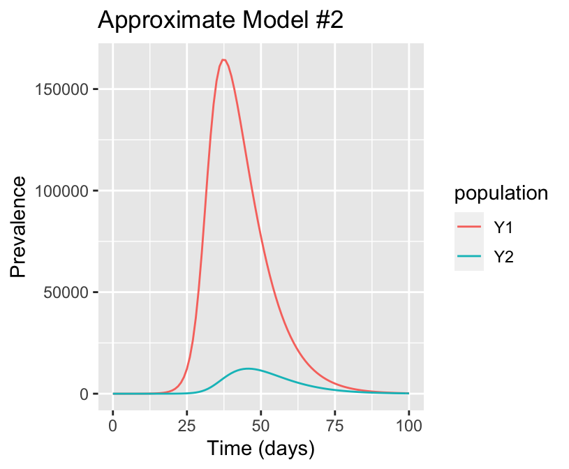

```r
sim20 %>% dplyr::select(time, Y1, Y2) %>%
  gather(key = population, value = number, Y1, Y2) %>%
  ggplot(aes(x = time, y = number, color = population, group = population)) +
  geom_line() + labs(x = "Time (days)", y = "Prevalence", title = "Approximate Model #2")
```

```r
sim2City <- seirNCity(num = 2, N = c(1e6, 1e6),
                      p = c(0.5, 0.95), I0 = c(1, 0),
                      fM = matrix(c(0.9, 0.1, 0.02, 0.98),
                                 nrow = 2, ncol = 2, byrow = FALSE), tf = 100)
```

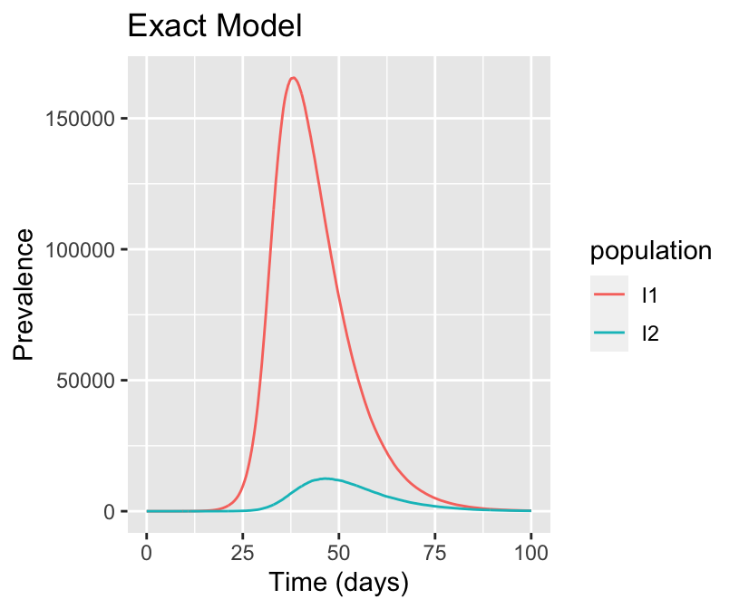

```r
sim2City %>% dplyr::select(time, I1, I2) %>%
  gather(key = population, value = number, I1, I2) %>%
  ggplot(aes(x = time, y = number, color = population, group = population)) + geom_line() +
  labs(x = "Time (days)", y = "Prevalence", title = "Exact Model")
```

Let’s see how this approximate n-city model compares with the stochastic three-city model.

```r
sim21 <- nCityApprox2(n = 3, N = c(1e6, 1e6, 1e6), v = c(0.95, 0.5, 0.95), Y0 = c(1, 0, 0),
         fM = matrix(c(0.998, 0.001, 0.001, 0.1, 0.9, 0, 0.1, 0, 0.9),
                     nrow = 3, ncol = 3, byrow = FALSE), tf = 150)
```

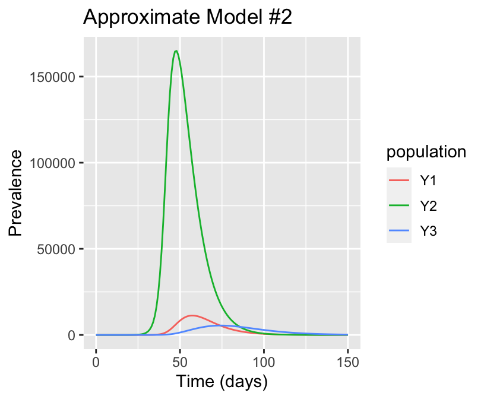

```r
sim21 %>% dplyr::select(time, Y1, Y2, Y3) %>%
  gather(key = population, value = number, Y1, Y2, Y3) %>%
  ggplot(aes(x = time, y = number, color = population, group = population)) +
  geom_line() + labs(x = "Time (days)", y = "Prevalence", title = "Approximate Model #2")
```

```r
sim3City <- seirNCity(num = 3, N = c(1e6, 1e6, 1e6),
                      p = c(0.95, 0.5, 0.95), I0 = c(0, 1, 0),
                      fM = matrix(c(0.998, 0.001, 0.001, 0.1, 0.9, 0, 0.1, 0, 0.9),
                                 nrow = 3, ncol = 3, byrow = FALSE), tf = 150)
```

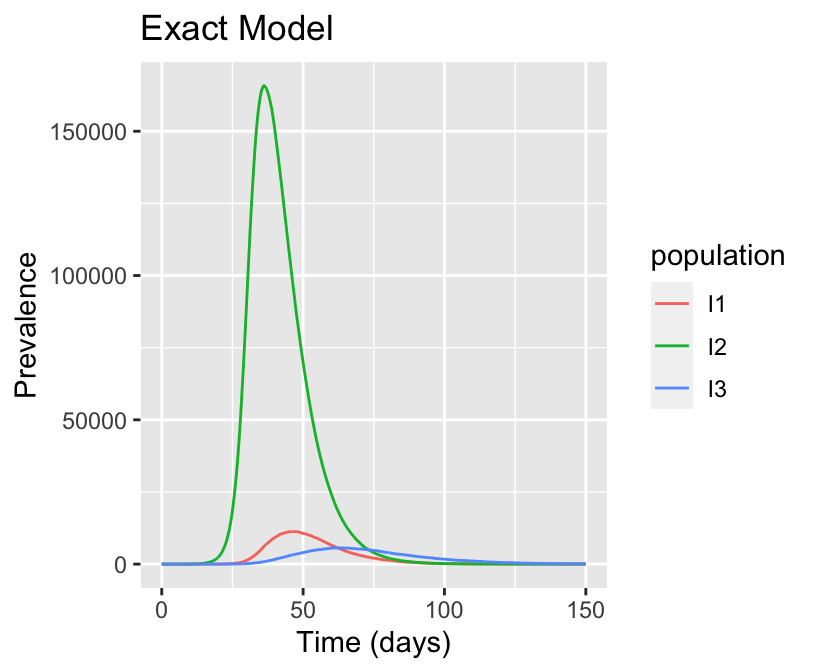

```r
sim3City %>% dplyr::select(time, I1, I2, I3) %>%
  gather(key = population, value = number, I1, I2, I3) %>%
  ggplot(aes(x = time, y = number, color = population, group = population)) +
  geom_line() + labs(x = "Time (days)", y = "Prevalence", title = "Exact Model")
```

```r
sim22 <- nCityApprox2(n = 4, N = c(1e6, 1e6, 1e6, 1e6), v = c(0.95, 0.5, 0.95, 0.95), Y0 = c(1, 1, 0, 0),
         fM = matrix(c(0.998, 0.001, 0.001, 0.001, 0.025, 0.9, 0.025, 0.05,
                       0.025, 0.025, 0.9, 0.05, 0.1, 0, 0, 0.9),
                     nrow = 4, ncol = 4, byrow = FALSE), tf = 200)
```